# `R` code to reproduce all results

This file contains code for reproducing results from Yan et al. ‘A quantitative synthesis of soil microbial effects on plant species coexistence’.

The html document mostly shows the output rather than the underlying code. **Click on the ‘Code’ button on the right to expand or hide the code.** Alternatively, you can directly run the code in the Rmd file, but please be aware that some code chunks may take a while to run for the first time (it may take more than 30 min to knit the entire document).

## Make conceptual figure (Fig 1)

### Make middle panel of Fig 1

The first goal is to make a base plot of stabilization/fitness differences onto which we can add species pairs. We will use this base plot to make the middle panel of **Figure 1**. This figure is also used later on to make Figure 4 in the paper.  
*Click `code` on the right to see the code for making the middle panel of Figure 1.*

```r
# Make a base plot that can be modified for each sub question
base_coex_plot <-
  ggplot() +
  geom_ribbon(aes(x = seq(0, 5, length.out = 100),
                  ymin = rep(0, length.out = 100),
                  ymax = seq(0, 5, length.out = 100)),
              fill = alpha("#CCEAC9", 1)) + #99D594 d9ead3ff
  geom_ribbon(aes(x = seq(0, -5, length.out = 100),
                  ymin = rep(0, length.out = 100),
                  ymax = seq(0, 5, length.out = 100)),
              fill = alpha("#FFFFBF", 1)) +
  annotate("segment", x = 0, y = 0, xend = 5, yend = 5, linetype = 2) +
  annotate("segment", x = 0, y = 0, xend = -5, yend = 5, linetype = 2) +
  geom_hline(yintercept = 0) +
  geom_vline(xintercept = 0) +
  xlab(bquote(atop("",
                   -frac(1,2)~(m["1A"]-m["1B"]-m["2A"]+m["2B"]) ))) +
  ylab(bquote(atop("Fitness difference",
                   frac(1,2)~(m["1A"]+m["1B"]-m["2A"]-m["2B"])))) +
  annotate("text", x = 0.2, y = -Inf, hjust = 0, vjust = 0, label = "Stabilization", color = "black", size = 4) +
  annotate("text", x = -0.2, y = -Inf, hjust = 1, vjust = 0, label = "Destabilization",  color = "black", size = 4) +
  annotate("segment", x = 0.2, xend = 1.25, y = -.12, yend = -.12,
           colour = "grey25", size = 0.5, arrow = arrow(length = unit(0.075, "inches"))) +
  annotate("segment", x = -0.2, xend = -1.25, y = -.12, yend = -.12,
           colour = "grey25", size = 0.5, arrow = arrow(length = unit(0.075, "inches"))) +
  theme_plots() +
  theme(axis.line = element_blank())
```

### Make trajectories (outer panels of Fig 1)

In Figure 1, we illustrate the possible outcomes of the plant-soil feedback model (coexistence/priority effects/exclusion). We use the base plot made above as the middle panel, and then add trajectories/graphics around the outside to illustrate potential outcomes.  
*Click `code` on the right to see the code for making the outer panels of Figure 1.*

```r
# Write a function that we can later use to simulate model dynamics using deSolve
psf_model <- function(time, init, params) {
  with (as.list(c(time, init, params)), {
    # description of parameters (see Bever et al. 1997)
    # pA: frequency of plant species 1; pB = 1-pA
    # m1A, m1B, m2A, m2B: conspecific and heterospecific effects of microbial community A or B on the growth of plant 1 or 2
    # pAlpha: frequency of the soil microbial community A
    # v: influence of plant species 2 on the microbial community relative to that of plant 1

    # Differential equations
    dpA <- pA*(1-pA)*((m1A-m1B)*pAlpha + (m2A-m2B)*(1-pAlpha))
    dpAlpha <- pAlpha*(1-pAlpha)*(pA-v*(1-pA))

    # Return dN1 and dN2
    return(list(c(dpA, dpAlpha)))
  })
}

# Function to calculate relevant metrics given a vector of m terms
metrics <- function(params) {
  IS <- with(as.list(params), {m1A - m2A - m1B + m2B})
  FD <- with(as.list(params), {(1/2)*(m1A+m2A) - (1/2)*(m1B+m2B)})
  SD <- (-1/2)*IS
  return(c(IS = IS, SD = SD, FD = FD))
}

# Define parameter values that result in different coexistence outcomes
params_coex = c(m1A = -.85, m1B = -.4, m2A = -.1, m2B = -.75, v = 1)
params_excl = c(m1A = -.55, m1B = -.7, m2A = -.1, m2B = -.85, v = 1)
params_priority = c(m1A = -0.2, m1B = -0.5, m2A = -0.8, m2B = -0.15, v = 1)
params_excl2 = c(m1A = -.1, m1B = -0.9, m2A = -.2, m2B = -.55, v = 1)

# define a time series and initial values of plant frequency.
# We will later use these to simulate the psf_model defined above.
time <- seq(0, 20, 0.1)
init = c(pA = 0.3, pAlpha = 0.3)

# run psf_model() using ode()
# we run several different scenarios using the parameter vectors defined above.
out_coex <- data.frame(ode(func = psf_model,
                                    y = init, times = time, parms = params_coex))
out_excl <- data.frame(ode(func = psf_model,
                                    y = init, times = time, parms = params_excl))

# For priority effects and exclusion with destabilization, we need to run two
# simulations with different initial conditions.
out_priority <- data.frame(ode(func = psf_model,
                                        y = init, times = time, parms = params_priority))

out_priority2 <- data.frame(ode(func = psf_model,
                                         y = c(pA = 0.7, pAlpha = 0.7),
                                         times = time, parms = params_priority))
out_excl2 <- data.frame(ode(func = psf_model,
                                     y = init, times = time, parms = params_excl2))
out_excl2b <- data.frame(ode(func = psf_model,
                                      y = c(pA = 0.7, pAlpha = 0.7),
                                      times = time, parms = params_excl2))


# Plotting --------
make_sim_plot <- function(desolve_out) {
  desolve_out$pB = 1-desolve_out$pA
  out_long <-
    desolve_out %>%
    select(-pAlpha) %>%
    pivot_longer(cols = pA:pB)
  sim1 <-
    ggplot(out_long) +
    geom_path(aes(x = time, y = value, color = name, linetype = name), size = 1) +
    scale_color_manual(values = c("#CC79A7", "#999999")) +
    ylim(0,1) +
    # ylab("Plant species frequency") +
    ylab("") +
    xlab("time") +
    scale_x_continuous(breaks = c(0, 20)) +
    scale_y_continuous(breaks = c(0, 0.5, 1.0)) +
    theme_plots() +
    theme(axis.title = element_text(size = 10))

  return(sim1)
}

make_params_plot <- function(params) {

  color_func <- function(x) {
    ifelse(x < 0, "darkred", "royalblue4")
  }
  df <- data.frame(x = c(0,0,1,1),
                   y = c(0,1,0,1),
                   type = c("M", "P", "M", "P"))

  params_plot <-
    ggplot(df) +
    annotate("text", x = 0, y = 1.15,  size = 3.15, label = "Plant 1") +
    annotate("text", x = 1, y = 1.15,  size = 3.15, label = "Plant 2") +
    annotate("text", x = 0, y = -0.15, size = 3.15, label = "\nSoil\nmicrobes A") +
    annotate("text", x = 1, y = -0.15, size = 3.15, label = "\nSoil\nmicrobes B") +
    geom_segment(aes(x = 0, xend = 0, y = 0.1, yend = 0.9),
                 arrow = arrow(length = unit(0.03, "npc")),
                 size = abs(params["m1A"]),
                 color = alpha(color_func(params["m1A"]), 1)) +
    geom_segment(aes(x = 0.05, xend = 0.95, y = 0.1, yend = 0.9),
                 arrow = arrow(length = unit(0.03, "npc")),
                 size = abs(params["m2A"]),
                 color = alpha(color_func(params["m1B"]),1)) +
    geom_segment(aes(x = 0.95, xend = 0.05, y = 0.1, yend = 0.9),
                 arrow = arrow(length = unit(0.03, "npc")),
                 size = abs(params["m1B"]),
                 color = alpha(color_func(params["m2A"]), 1)) +
    geom_segment(aes(x = 1, xend = 1, y = 0.1, yend = 0.9),
                 arrow = arrow(length = unit(0.03, "npc"), type = "closed"),
                 size = abs(params["m2B"]),
                 color = alpha(color_func(params["m2B"]), 1)) +

    # Plant cultivation of microbes
    geom_segment(aes(x = -0.35, xend = -0.35, y = 0.9, yend = 0.1), size = 0.15, linetype = 1,
                 arrow = arrow(length = unit(0.03, "npc"))) +
    geom_segment(aes(x = 1.35, xend = 1.35, y = 0.9, yend = 0.1), size = 0.15, linetype = 1,
                 arrow = arrow(length = unit(0.03, "npc"))) +

    annotate("text", x = 0, y = 0.5,
             label = TeX(paste0(params["m1A"])),
             angle = 90, vjust = -0.25, size = 3) +
    annotate("text", x = 1, y = 0.5,
             label = TeX(paste0(params["m2B"])),
             angle = 90, vjust = 1.5, size = 3) +
    annotate("text", x = 0.75, y = 0.75,
             label = TeX(paste0(params["m2A"])),
             label = TeX(paste0("m_{2A} = ", params["m2A"])),
             angle = 40, vjust = -0.25, size = 3) +
    annotate("text", x = 0.25, y = 0.75,
             label = TeX(paste0(params["m1B"])),
             angle = -40, vjust = -0.25, size = 3) +
    xlim(c(-0.4, 1.4)) +
    coord_cartesian(ylim = c(-0.25, 1.25), clip = "off") +
    theme_void() +
    theme(legend.position = "none",
          plot.caption = element_text(hjust = 0.5, size = 10))
  return(params_plot)
}


plot_traj1 <- make_sim_plot(out_coex)  +
  scale_y_continuous(breaks = c(0, 0.5, 1), limits = c(0,1))
plot_traj2 <- make_sim_plot(out_excl)
plot_traj3 <- {make_sim_plot(out_priority) +
    labs(subtitle = "Note that outcome depends\non initial population sizes")} +
  {make_sim_plot(out_priority2)}
plot_traj4 <- {make_sim_plot(out_excl2)  +
    labs(subtitle = "Note that outcome is independent\nof initial population sizes")} +
  {make_sim_plot(out_excl2b) }
```

### Assemble panels for Fig 1

Next, we need to assemble the outer and middle panels into one figure to make the final version of Fig. 1.  
*Click `code` on the right to see the code for assembling the panels together for Figure 1. The resulting plot is shown below:*

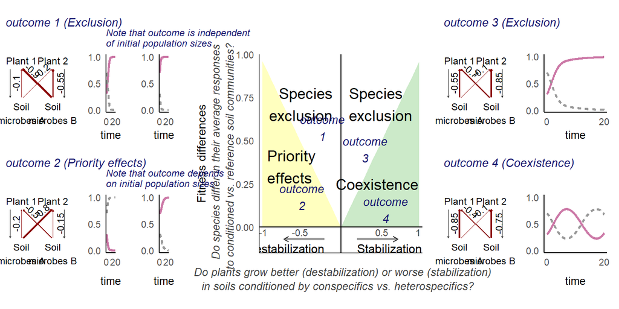

```r
fig1_middle <-
  base_coex_plot +
  labs(
    x = "<span style = 'font-size:10pt;color:grey25;'>
    *Do plants grow better (destabilization) or worse (stabilization)<br>
    in soils conditioned by conspecifics vs. heterospecifics?*
    </span>",

    y = "Fitness differences<br>
    <span style = 'font-size:10pt;color:grey25;''>
    *Do species differ in their average responses<br>
    to conditioned vs. reference soil communities?*
    </span>",

  ) +
  annotate("text", x = 0.9, y = 0.25, hjust = 0.95,
           label = "Coexistence", size = 5) +
  annotate("text", x = 0.1, y = Inf, vjust = 2, hjust = 0,
           label = "Species\nexclusion", size = 5) +
  annotate("text", x = -0.1, y = Inf, vjust = 2, hjust = 1,
           label = "Species\nexclusion", size = 5) +
  annotate("text", x = -0.9, y = 0.35, hjust = 0,
           label = "Priority\neffects", size = 5) +
  annotate("text", label = "outcome\n1", fontface = "italic", color = "midnightblue",
           x = metrics(params_excl2)["SD"],
           y = abs(metrics(params_excl2)["FD"])) +
  annotate("text", label = "outcome\n2", fontface = "italic", color = "midnightblue",
           x = metrics(params_priority)["SD"],
           y = abs(metrics(params_priority)["FD"])) +
  annotate("text", label = "outcome\n3", fontface = "italic", color = "midnightblue",
           x = metrics(params_excl)["SD"],
           y = metrics(params_excl)["FD"]) +
  annotate("text", label = "outcome\n4", fontface = "italic", color = "midnightblue",
           x = metrics(params_coex)["SD"],
           y = metrics(params_coex)["FD"]) +
  annotate("text", label = c("-1", "-0.5", "0.5", "1"),
           x = c(-0.95, -0.5, 0.5, 0.95), y = -.03, color = "grey25", size = 3) +
  scale_x_continuous(limits = c(-1,1), expand = c(0,0)) +
  scale_y_continuous(limits = c(-0.15,1), expand = c(0,0)) +
  annotate("segment", x = 0.2, xend = 0.7, y = -.07, yend = -.07,
           colour = "grey25", size = 0.5, arrow = arrow(length = unit(0.075, "inches"))) +
  annotate("segment", x = -0.2, xend = -.7, y = -.07, yend = -.07,
           colour = "grey25", size = 0.5, arrow = arrow(length = unit(0.075, "inches"))) +

  theme(axis.line = element_line(size = 0),
        plot.margin = margin(r = 20, t = 0, b = 10, l = 20),
        axis.text.x = element_blank(),
        axis.title.x = element_textbox_simple(
          width = NULL, halign = 0.5),
        axis.title.y = element_textbox_simple(
          width = NULL, halign = 0.5, orientation = "left-rotated"))



panelB <- {make_params_plot(params_excl2)    +labs(title = "outcome 1 (Exclusion)")} + {plot_traj4}
panelC <- {make_params_plot(params_priority) +labs(title = "outcome 2 (Priority effects)")} + {plot_traj3}
panelD <- {make_params_plot(params_excl)     +labs(title = "outcome 3 (Exclusion)")} + {plot_traj2}
panelE <- {make_params_plot(params_coex)     +labs(title = "outcome 4 (Coexistence)")} + {plot_traj1}

layout <- "
BBBBBBBAAAAAAADDDDDDD
BBBBBBBAAAAAAADDDDDDD
BBBBBBBAAAAAAADDDDDDD
BBBBBBBAAAAAAADDDDDDD
CCCCCCCAAAAAAAEEEEEEE
CCCCCCCAAAAAAAEEEEEEE
CCCCCCCAAAAAAAEEEEEEE
CCCCCCCAAAAAAAEEEEEEE
"

(full_plot <-
    {fig1_middle} +
    {panelB} +
    {panelC} +
    {panelD} +
    {panelE} +
    plot_layout(design = layout) &
    theme(legend.position = "none",
          plot.subtitle = element_text(face = "italic", color = "midnightblue", size = 9),
          plot.title = element_text(face = "italic", color = "midnightblue", size = 11),
          plot.tag = element_text(size = 12))
)
```

```r
if(save_figures) {
  ggsave('figures/fig1.png', width = 13/1.15, height = 5/1.15, bg = "transparent")
  ggsave('figures/fig1.pdf', width = 13/1.15, height = 5/1.15, bg = "transparent")
  ggsave('figures/fig1.tiff', width = 13*1.15, height = 5*1.15, bg = "transparent",
          dpi=300, compression = "lzw")
  ggsave('figures/fig1.eps', width = 13*1.15, height = 5*1.15, bg = "transparent")
}
```

### Figure S.1: Coexistence outcomes with positive microbial effects

Next we made another conceptual figure, but this time, show all four outcomes using positive values of all $m$ terms.  
*Click `code` on the right to see the code for generating and assembling Figure S1.*

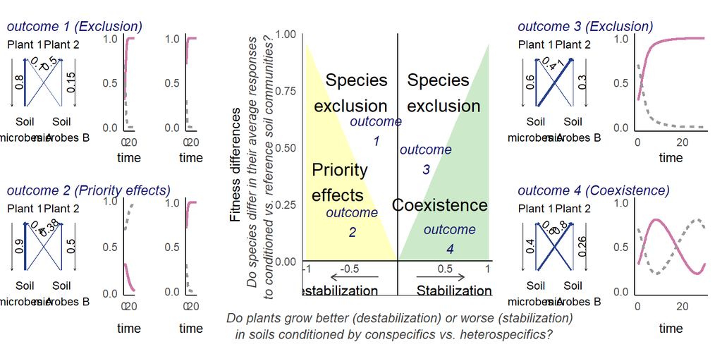

```r
# defining parameters (positive m terms) for different competitive outcomes
params_coex = c(m1A = .2*2, m1B = 0.3*2, m2A = .4*2, m2B = .13*2, v = 1)
params_excl = c(m1A = .3*2, m1B = .2*2, m2A = 0.5*2, m2B = .15*2, v = 1)
params_priority = c(m1A = .9, m1B = 0.4, m2A = 0.38, m2B = 0.5, v = 1)
params_excl2 = c(m1A = .8, m1B = 0.1, m2A = 0.5, m2B = .15, v = 1)
time <- seq(0, 30,.1)
init = c(pA = 0.3, pAlpha = 0.3)

# run the previously defined psf_model() function with deSolve::ode()
out_coex <- data.frame(ode(func = psf_model,
                           y = init, times = time, parms = params_coex))
out_excl <- data.frame(ode(func = psf_model,
                           y = init, times = time, parms = params_excl))
out_priority <- data.frame(ode(func = psf_model,
                               y = init, times = time, parms = params_priority))

out_priority2 <- data.frame(ode(func = psf_model,
                                y = c(pA = 0.7, pAlpha = 0.7),
                                times = time, parms = params_priority))
out_excl2 <- data.frame(ode(func = psf_model,
                            y = init, times = time, parms = params_excl2))
out_excl2b <- data.frame(ode(func = psf_model,
                             y = c(pA = 0.7, pAlpha = 0.7),
                             times = time, parms = params_excl2))


# Plotting --------
plot_traj1 <- make_sim_plot(out_coex) +
  scale_y_continuous(breaks = c(0, 0.5, 1), limits = c(0,1))
plot_traj2 <- make_sim_plot(out_excl)
plot_traj3 <- {make_sim_plot(out_priority) } +
  {make_sim_plot(out_priority2) }
plot_traj4 <- {make_sim_plot(out_excl2) } +
  {make_sim_plot(out_excl2b)}

panelB <- {make_params_plot(params_excl2) + labs(title = "outcome 1 (Exclusion)")} +
  {plot_traj4}
panelC <- {make_params_plot(params_priority) + labs(title = "outcome 2 (Priority effects)")} +
  {plot_traj3}
panelD <- {make_params_plot(params_excl) + labs(title = "outcome 3 (Exclusion)")} +
  {plot_traj2}
panelE <- {make_params_plot(params_coex) + labs(title = "outcome 4 (Coexistence)")} +
  {plot_traj1}

(full_plot <-
    {fig1_middle} +
    {panelB} +
    {panelC} +
    {panelD} +
    {panelE} +
    plot_layout(design = layout) &
    theme(legend.position = "none", # plot.title.position = "plot",
          plot.subtitle = element_text(face = "italic", color = "midnightblue", size = 12),
          plot.title = element_text(face = "italic", color = "midnightblue", size = 11),
          plot.tag = element_text(size = 12))
)
```

```r
if(save_figures) {
  ggsave('figures/fig1_MutualismsVersion.png', width = 13/1.15, height = 5/1.15, bg = "transparent")
  ggsave('figures/fig1_MutualismsVersion.pdf', width = 13/1.15, height = 5/1.15, bg = "transparent")
}
```

## Begin data analysis

### Define useful functions to run the analyses downstream

Before importing and analyzing data, we first define a few custom functions that help with analyses. The first function uses the underlying data (mean and SE biomass of plants different species-soil combinations to calculate the effect sizes (stabilization and fitness differences, and their variances)). These effect sizes are the basis for the multivariate mixed-effect meta-analyses in Q1 and Q2. The second function implements the simulation-based approach for quantifying pairwise coexistence outcomes for each species pair using the underlying biomass data. This approach is used for Q2 (Figure 4).  
*Click `code` on the right to see these two functions.*

```r
# Define a new function that takes as its input the data file
# and uses the columns `AinA mean`, `AinA se`, .... to calculate the
# stabilization and fitness difference metrics (as well as the variance)
calculate_effect_sizes <- function(data){
  # data: each row is a species pair, with growth data (mean, se, n)
  #       of each species in conspecific, heterospecific, and control soil

  data_with_SDFD <- data %>%
    mutate( # mean stabilization, which is also -1/2 of Is
      mean_SD = -1/2*(log(`AinA mean`) - log(`AinB mean`) -
                        log(`BinA mean`) + log(`BinB mean`) ),
      IS = -2*mean_SD,
      # variance of the SD effect size
      # note that this is 1/4 of the var(rrIs) in Crawford et al. 2019
      # note that `AinA var`/`AinA N = `AinA se`^2
      var_SD = 1/4*`AinA se`^2/`AinA mean`^2 +
        1/4*`AinB se`^2/`AinB mean`^2 +
        1/4*`BinA se`^2/`BinA mean`^2 +
        1/4*`BinB se`^2/`BinB mean`^2,
      # note that the above is the variance of the mean estimate,
      # i.e. the square of the "Standard Error of the Mean" for SD effect size
      sem_SD = sqrt(var_SD),

      # next, fitness difference (FD) effect size
      mean_FD = 1/2*(log(`AinA mean`) + log(`AinB mean`) -
                       2*log(`AinR mean`) - log(`BinA mean`) -
                       log(`BinB mean`) + 2*log(`BinR mean`) ),
      # calculate the variance & SEM of the FD effect size
      # Derivations (2 ways) are shown in variance_logRR file
      var_FD = 1/4*`AinA se`^2/`AinA mean`^2 +
        1/4*`AinB se`^2/`AinB mean`^2 +
        1/4*`BinA se`^2/`BinA mean`^2 +
        1/4*`BinB se`^2/`BinB mean`^2 +
        `AinR se`^2/`AinR mean`^2 +
        `BinR se`^2/`BinR mean`^2,
      # "Standard Error of the Mean" for FD effect size
      sem_FD = sqrt(var_FD),

      # absolute value of FD
      abs_FD = abs(mean_FD),

      # IGR & its SEM
      mean_IGR = mean_SD - abs_FD,
      var_IGR = var_SD + var_FD,
      sem_IGR = sqrt(var_IGR),


    )
  return(data_with_SDFD)
}

# Define a function to run the sampling approach for Q2
simulation_ci <- function(data_with_SDFD) {
  n_reps <- 10000
  set.seed(31415)
  to_return <- data_with_SDFD


  # First we need to define new columns that quantify the SD of
  # the relevant biomass values. Here, the standard error of the mean from the
  # original study is divided by the mean value to back-calculate
  # the standard deviations of the log(biomass) values.
  # See Appendix 2 for derivations/justifications.
  data_with_SDFD$sd_logAinA = data_with_SDFD$`AinA se`/data_with_SDFD$`AinA mean`
  data_with_SDFD$sd_logAinB = data_with_SDFD$`AinB se`/data_with_SDFD$`AinB mean`
  data_with_SDFD$sd_logAinR = data_with_SDFD$`AinR se`/data_with_SDFD$`AinR mean`
  data_with_SDFD$sd_logBinA = data_with_SDFD$`BinA se`/data_with_SDFD$`BinA mean`
  data_with_SDFD$sd_logBinB = data_with_SDFD$`BinB se`/data_with_SDFD$`BinB mean`
  data_with_SDFD$sd_logBinR = data_with_SDFD$`BinR se`/data_with_SDFD$`BinR mean`

  # BEGIN SAMPLING APPROACH
  # First we use the biomass values (mean and SD) to generate new vectors
  # of possible values
  biomass_AinA_list <- lapply(1:nrow(data_with_SDFD), function(x)
    rnorm(n_reps, mean = log(data_with_SDFD$`AinA mean`[x]),
          sd = data_with_SDFD$sd_logAinA[x]))
  biomass_AinB_list <- lapply(1:nrow(data_with_SDFD), function(x)
    rnorm(n_reps, mean = log(data_with_SDFD$`AinB mean`[x]),
          sd = data_with_SDFD$sd_logAinB[x]))
  biomass_AinR_list <- lapply(1:nrow(data_with_SDFD), function(x)
    rnorm(n_reps, mean = log(data_with_SDFD$`AinR mean`[x]),
          sd = data_with_SDFD$sd_logAinR[x]))
  biomass_BinA_list <- lapply(1:nrow(data_with_SDFD), function(x)
    rnorm(n_reps, mean = log(data_with_SDFD$`BinA mean`[x]),
          sd = data_with_SDFD$sd_logBinA[x]))
  biomass_BinB_list <- lapply(1:nrow(data_with_SDFD), function(x)
    rnorm(n_reps, mean = log(data_with_SDFD$`BinB mean`[x]),
          sd = data_with_SDFD$sd_logBinB[x]))
  biomass_BinR_list <- lapply(1:nrow(data_with_SDFD), function(x)
    rnorm(n_reps, mean = log(data_with_SDFD$`BinR mean`[x]),
          sd = data_with_SDFD$sd_logBinR[x]))

  # Use the new vectors created above to go from biomass values to
  # estimates of m terms:
  # (m1A = biomass(plant 1, soil A) - biomass(plant 1, reference soil))
  mAA_vec <- mapply("-", biomass_AinA_list, biomass_AinR_list, SIMPLIFY = F)
  mAB_vec <- mapply("-", biomass_AinB_list, biomass_AinR_list, SIMPLIFY = F)
  mBA_vec <- mapply("-", biomass_BinA_list, biomass_BinR_list, SIMPLIFY = F)
  mBB_vec <- mapply("-", biomass_BinB_list, biomass_BinR_list, SIMPLIFY = F)

  # Define functions that use m terms to calculate
  # stabilization and fitness difference
  SD_calc <- function(mAA, mAB, mBA, mBB) {
    -0.5*(mAA - mAB - mBA + mBB)
  }
  FD_calc <- function(mAA, mAB, mBA, mBB) {
    0.5*(mAA + mAB) - 0.5*(mBA + mBB)
  }

  # Use newly defined functions to calculate SD and FD
  SD_vec_matrix <- mapply(SD_calc, mAA_vec, mAB_vec, mBA_vec, mBB_vec, SIMPLIFY = T)
  FD_vec_matrix <- mapply(FD_calc, mAA_vec, mAB_vec, mBA_vec, mBB_vec, SIMPLIFY = T)

  SD_vec_by_species <- split(SD_vec_matrix, col(SD_vec_matrix))
  FD_vec_by_species <- split(FD_vec_matrix, col(FD_vec_matrix))

  SD_vec_by_run <- split(SD_vec_matrix, row(SD_vec_matrix))
  FD_vec_by_run <- split(FD_vec_matrix, row(FD_vec_matrix))

  compare <- function(FD_vec, SD_vec) {
    exclusion <- sum(abs(FD_vec) > abs(SD_vec))
    coexistence <- sum(abs(FD_vec) < SD_vec)
    priority <- length(FD_vec)-(exclusion+coexistence)
    return(c(n_reps_exclusion = exclusion, n_reps_coex = coexistence,
             n_reps_pes = priority))
  }


  outcomes_by_pair <- t(mapply(compare, FD_vec_by_species, SD_vec_by_species))
  outcomes_by_run <- t(mapply(compare, FD_vec_by_run, SD_vec_by_run))
  to_return <- cbind(to_return, outcomes_by_pair)

  return(list(outcomes_by_pair = to_return,
              outcomes_by_run = as.data.frame(outcomes_by_run)))
}
```

### Read in datasets

For this analysis, we are working with two complementary datasets. The first is the dataset of SD/FD effect sizes with field live soil as the reference; the second set of effect sizes are from studies with sterile soils as reference inoculua. The number of rows in each of these datasets is shown below.

```r
# examine how many species pairs are there in live vs. sterile reference dataset
bind_rows(sterile_ref, live_ref, .id = "reference_type") %>%
  mutate(reference_type = ifelse(reference_type == 1, "sterile soil", "live soil")) %>%
  group_by(reference_type) %>%
  summarize(n_rows = n()) %>%
  kable() %>%
  kable_styling(full_width = FALSE)
```

| reference_type | n_rows |
| --- | --- |
| live soil | 72 |
| sterile soil | 449 |

Note that there are 449 comparisons in the sterile soil dataset right now, but there are three comparisons we will eventually need to exclude because of unreliable data, see below.

### Explore data availability and patterns

We can first get a lay of the land on this dataset by checking how many species there are, from how many experiments, and from how many studies. We used these numbers to make the tables in Figure 2.  
*Click `code` on the right to see how these numbers are generated.*

```r
# Total number of effect sizes:
# FIElD LIVE REFERENCE
# first, across the whole dataset
cat("**Live soil reference**")
```

**Live soil reference**

```r
cat(paste0("&emsp; Number of unique comparisons in Live ref dataset: ",
           nrow(live_ref)))
```

Number of unique comparisons in Live ref dataset: 72

```r
# Number of unique species pairs
cat(paste0("&emsp; Number of unique species pairs in Live ref dataset: ",
           live_ref$species_pair %>% unique %>% length))
```

Number of unique species pairs in Live ref dataset: 69

```r
# Number of unique Studies
cat(paste0("&emsp; Number of unique studies in Live ref dataset: ",
           live_ref$Study %>% unique %>% length))
```

Number of unique studies in Live ref dataset: 16

```r
# Number of unique Experiments
cat(paste0("&emsp; Number of unique experiments in Live ref dataset: ",
           live_ref$Experiment %>% unique %>% length))
```

Number of unique experiments in Live ref dataset: 18

```r
cat("----------")
```

```r
# STERILE SOIL REFERENCE
# first, across the whole dataset
cat("**Sterile soil reference**")
```

**Sterile soil reference**

```r
cat(paste0("&emsp; Number of unique comparisons in Sterile ref dataset: ",
           nrow(sterile_ref)))
```

Number of unique comparisons in Sterile ref dataset: 449

```r
# Number of unique species pairs
cat(paste0("&emsp; Number of unique species pairs in Sterile ref dataset: ",
           sterile_ref$species_pair %>% unique %>% length))
```

Number of unique species pairs in Sterile ref dataset: 213

```r
# Number of unique Studies
cat(paste0("&emsp; Number of unique studies in Sterile ref dataset: ",
           sterile_ref$Study %>% unique %>% length))
```

Number of unique studies in Sterile ref dataset: 38

```r
# Number of unique Experiments
cat(paste0("&emsp; Number of unique experiments in Sterile ref dataset: ",
           sterile_ref$Experiment %>% unique %>% length))
```

Number of unique experiments in Sterile ref dataset: 67

We can also do some summaries of the 4-5 moderators we are going to use later on in the analysis.

First for the **Live reference** dataset:

```r
# how many pairwise comparisons are there that used Lab vs. Field training environment?
live_ref %>%
  group_by(`Training environment`) %>%
  summarize(n_rows = n()) %>%
  kable() %>% kable_styling(full_width = F)
```

| Training environment | n_rows |
| --- | --- |
| Field | 14 |
| Lab | 58 |

```r
# how many pairwise comparisons are there that used Low vs. High fraction inoculum?
live_ref %>%
  mutate(inoc_frac_binary = ifelse(`Fraction inoculum` <= 0.25, "low", "high")) %>%
  group_by(inoc_frac_binary) %>%
  summarize(n_rows = n()) %>%
  kable() %>% kable_styling(full_width = F)
```

| inoc_frac_binary | n_rows |
| --- | --- |
| high | 55 |
| low | 17 |

```r
# how many pairwise comparisons are there that grew phase-2 species in individual, population, or community?
live_ref %>%
  group_by(`Testing community`) %>%
  summarize(n_rows = n()) %>%
  kable() %>% kable_styling(full_width = F)
```

| Testing community | n_rows |
| --- | --- |
| Community | 15 |
| Individual | 55 |
| Population | 2 |

And next for the **Sterile reference** dataset:

```r
# # of pairwise comparisons using Lab vs. Field training environment?
sterile_ref %>%
  group_by(`Training environment`) %>%
  summarize(n_rows = n()) %>%
  kable() %>% kable_styling(full_width = F)
```

| Training environment | n_rows |
| --- | --- |
| Field | 178 |
| Lab | 235 |
| LabField | 36 |

```r
# # of pairwise comparisons using Low vs. High fraction inoculum?
sterile_ref %>%
  mutate(inoc_frac_binary = ifelse(`Fraction inoculum` <= 0.25, "low", "high")) %>%
  group_by(inoc_frac_binary) %>%
  summarize(n_rows = n()) %>%
  kable() %>% kable_styling(full_width = F)
```

| inoc_frac_binary | n_rows |
| --- | --- |
| high | 118 |
| low | 331 |

```r
# # of pairwise comparisons grew in individual, population, vs. community?
sterile_ref %>%
  group_by(`Testing community`) %>%
  summarize(n_rows = n()) %>%
  kable() %>% kable_styling(full_width = F)
```

| Testing community | n_rows |
| --- | --- |
| Community | 220 |
| Individual | 192 |
| Population | 37 |

```r
# # of pairwise comparisons using different types soil as sterile reference?
cat("Note that in the following table, CmS = cultivated, mixed, sterile; CS = cultivated sterile, FS = field sterile soil, GS = greenhouse sterile soil")
```

Note that in the following table, CmS = cultivated, mixed, sterile; CS = cultivated sterile, FS = field sterile soil, GS = greenhouse sterile soil

```r
sterile_ref %>%
  group_by(control_type) %>%
  summarize(n_rows = n()) %>%
  kable() %>% kable_styling(full_width = F)
```

| control_type | n_rows |
| --- | --- |
| CmS | 15 |
| CS | 197 |
| FS | 20 |
| GS | 217 |

```r
# # of pairwise comparisons using different types of sterilization methods?
sterile_ref %>%
  group_by(Study_sterilization_method) %>%
  summarize(n_rows = n()) %>%
  kable() %>% kable_styling(full_width = F)
```

| Study_sterilization_method | n_rows |
| --- | --- |
| autoclaving | 120 |
| gamma irradiation | 122 |
| heating | 189 |
| not specified | 3 |
| pasteurization | 6 |
| steam-pasteurization | 1 |
| steaming | 8 |

Note that in analyses below, “not specified”, “pasteurization”, “steam-pasteurization”, and “steaming” will be grouped as “other”.

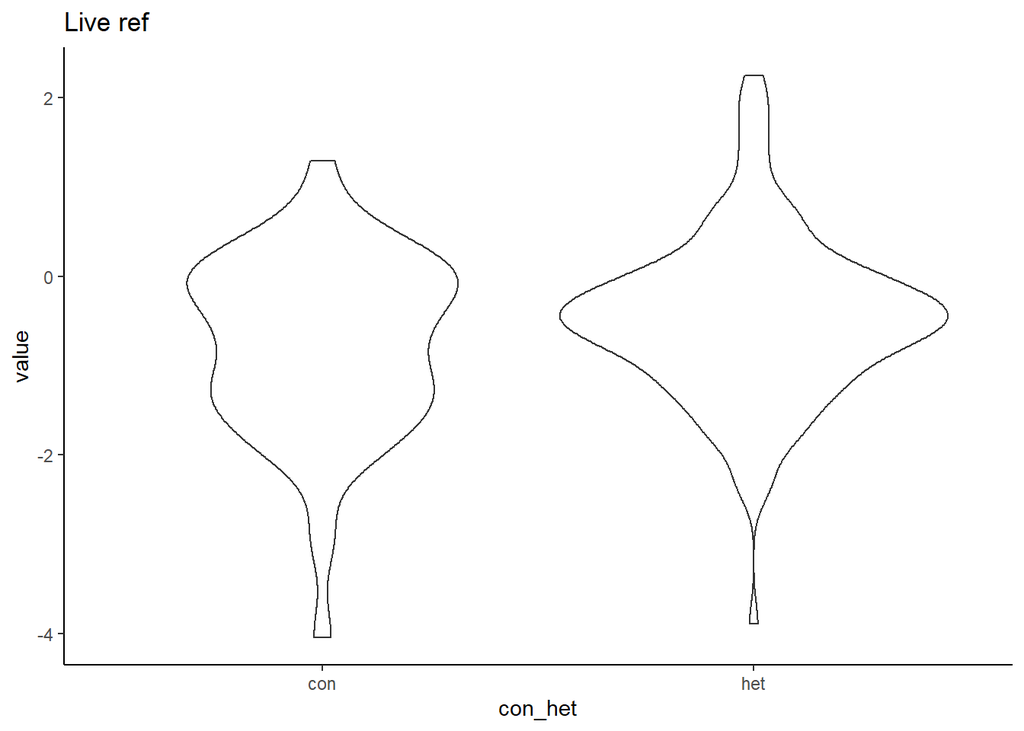

```r
# magnitude of con- vs. hetero-specific effects in the live reference dataset
live_ref %>%
  mutate(m1A = log(`AinA mean`) - log(`AinR mean`),
         m1B = log(`AinB mean`) - log(`AinR mean`),
         m2A = log(`BinA mean`) - log(`BinR mean`),
         m2B = log(`BinB mean`) - log(`BinR mean`)) %>%
  select(m1A:m2B) %>%
  pivot_longer(cols = m1A:m2B, names_to = "which_metric") %>%
  mutate(con_het = ifelse(which_metric %in% c("m1A", "m2B"), "con", "het")) %>%
  ggplot() +
  geom_violin(aes(y = value, x = con_het)) +
  labs(title = "Live ref") +
  theme_classic()
```

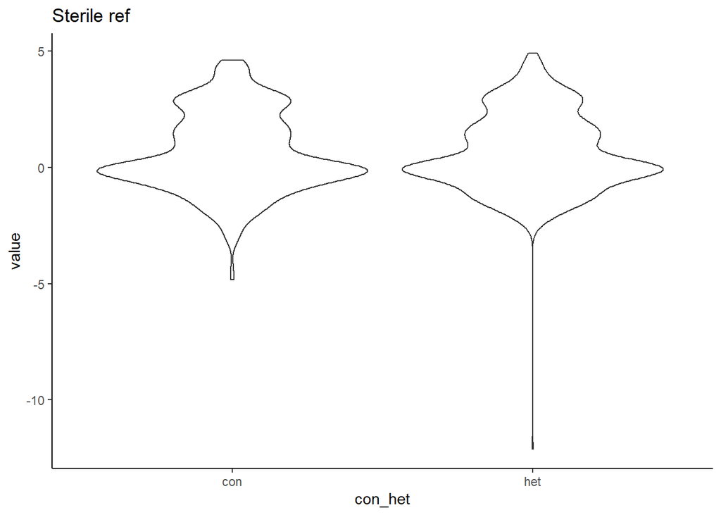

```r
# Slightly more positive (less negative) heterospecific effects than
# conspecific effects, consistent with stabilization

# magnitude of con- vs. hetero-specific effects in the sterile reference dataset
sterile_ref %>%
  mutate(m1A = log(`AinA mean`) - log(`AinR mean`),
         m1B = log(`AinB mean`) - log(`AinR mean`),
         m2A = log(`BinA mean`) - log(`BinR mean`),
         m2B = log(`BinB mean`) - log(`BinR mean`)) %>%
  select(m1A:m2B) %>%
  pivot_longer(cols = m1A:m2B, names_to = "which_metric") %>%
  mutate(con_het = ifelse(which_metric %in% c("m1A", "m2B"), "con", "het")) %>%
  ggplot() +
  geom_violin(aes(y = value, x = con_het)) +
  labs(title = "Sterile ref") +
  theme_classic()
```

There is one species pair with an extreme outlier in the heterospecific effects column. We need to look into what is happening here. This is the pair from McCarthy-Neumann and Kobe (2010)’s study, where the paper has no value for plant growth, which was interpreted as zero growth in Crawford et al’s dataset.

```r
# order m2A values in the dataset, the outlier shows up on top
sterile_ref %>%
  mutate(m1A = log(`AinA mean`) - log(`AinR mean`),
         m1B = log(`AinB mean`) - log(`AinR mean`),
         m2A = log(`BinA mean`) - log(`BinR mean`),
         m2B = log(`BinB mean`) - log(`BinR mean`)) %>%
   select(Study, author, year, species_pair,
          `AinA mean`,`AinB mean`, `AinR mean`, `BinA mean`, `BinB mean`, `BinR mean`,
          m1A:m2B) %>%
  arrange(m2A)
```

```
## # A tibble: 449 x 14
##    Study author            year species_pair `AinA mean` `AinB mean` `AinR mean`
##    <dbl> <chr>            <dbl> <chr>              <dbl>       <dbl>       <dbl>
##  1    38 McCarthy-Neuman~  2010 colubrina_s~      33.8        20.1        32.9
##  2   507 Png et al.        2018 banksia_lep~      10.7         9.77       22.8
##  3    51 Hendriks et al    2013 leucanthemu~       0.015       0.096       0.321
##  4    51 Hendriks et al    2013 anthoxanthu~       0.027       0.025       0.233
##  5    77 Petermann et al   2008 festuca_rub~       0.119       0.131       0.529
##  6    77 Petermann et al   2008 lepidium_ca~       0.121       0.098       0.729
##  7    77 Petermann et al   2008 berteroa_in~       0.116       0.352       0.374
##  8   507 Png et al.        2018 acacia_spat~       2.60        2.67        6.42
##  9   507 Png et al.        2018 acacia_spat~       2.60        2.82        6.42
## 10   507 Png et al.        2018 calothamnus~       1.60        2.62       11.1
## # ... with 439 more rows, and 7 more variables: `BinA mean` <dbl>,
## #   `BinB mean` <dbl>, `BinR mean` <dbl>, m1A <dbl>, m1B <dbl>, m2A <dbl>,
## #   m2B <dbl>
```

That does appear to be the case, the pair with the really low value is `colubrina_spinosa_iriartea_deltoidea`, for which no data for one species as interpreted as 0 biomass. From personal conversations with the author of the original study (GK meeting with McCarthy-Neumann at ESA 2019), this was just “no data” likely because of bad seeds rather than microbial effects.

There is also one species pair (`rumex_occidentalis_rumex_salicifolius`) for which there is always zero growth in reference soil. This is not usable because the value for SE is zero, making it impossible to use in the meta-analysis. We can remove those points here.

```r
# manually removing the two identified outliers
sterile_ref <-
  sterile_ref %>%
  filter(!(species_pair %in% c("colubrina_spinosa_iriartea_deltoidea",
                                 "rumex_occidentalis_rumex_salicifolius")))
```

Removing those unusable data points leaves us with **446** pairwise comparisons in the Sterile Ref dataset.

## Question 1

Now that the data look in good shape, we are ready to quantify the effect sizes (magnitude of (de)stabilization and fitness differences).

### Calculate effect sizes (SD/FD) from biomass

To calculate effect sizes, we use a function defined in the earlier section for function definitions. *Click on `code` to the right to see how the function `calculate_effect_sizes()` is used to calculate effect sizes from biomass values.*

```r
# Use the above-deined functions to calculate niche and fitness difference
# The function makes a new dataframe, so let's use that to override the
# existing one.
live_ref <- calculate_effect_sizes(live_ref)
# The new columns are:
# mean_SD, IS, var_SD, sem_SD; mean_FD, var_FD, sem_FD,
# abs_FD, mean_IGR, var_IGR, sem_IGR

# repeat for sterile dataset
sterile_ref <- calculate_effect_sizes(sterile_ref)
```

### Prepare the datasets for meta-analysis

Right now the datasets are in “wide” format, with each row containing a species pair with it’s stabilization and fitness difference measures in separate columns. We need to make this into a long format dataframe with each species pair having two rows (one for stabilization, one for fitness differences). *Click `code` to the right to see how data are reshaped into long format*.

```r
# Make a dataset in 'long' format with all effect sizes
# in one column, a moderator column that specifies whether it is FD/SD,
live_ref_long <-
  live_ref %>%
  select(Experiment, Study, species_pair, author,
         mean_SD, mean_FD, var_SD, var_FD,
         `Fraction inoculum`, `Training environment`, `Testing environment`,
         Study_sterilization_method, `Testing community`) %>%
  pivot_longer(cols = mean_SD:var_FD,
               names_to = c(".value","set"),
               names_pattern = "(.+)_(.+)")  %>%
  rename(mean_value = mean, var_value = var) %>%
  mutate(
    # Make a new column with absolute value of FD, and `real` value of SD
    absolute_FD_effect = ifelse(set == "FD", abs(mean_value), mean_value),
    # Make a new column with absolute value of both SD and FD
    absolute_FDSD_effects = abs(mean_value),
    # Make a new column with just effect size ID (to act as ranef)
    ES_ID = 1:nrow(.),
    # Make a new column for each species pair within a study
    Experiment_SpPair = paste0(Experiment, "_", species_pair)
  )



# Do the same process for the sterile reference dataset:

# Make a dataset in 'long' format with all effect sizes
# in one column, a moderator column that specifies whether it is FD/SD,

sterile_ref_long <-
  sterile_ref %>%
  select(Experiment, Study, author, species_pair,
         mean_SD, mean_FD, var_SD, var_FD,
         `Fraction inoculum`, `Training environment`, `Testing environment`, control_type,
         Study_sterilization_method, `Testing community`) %>%
  pivot_longer(cols = mean_SD:var_FD,
               names_to = c(".value","set"),
               names_pattern = "(.+)_(.+)")  %>%
  rename(mean_value = mean, var_value = var) %>%
  mutate(
    # Make a new column with absolute value of FD, and `real` value of SD
    absolute_FD_effect = ifelse(set == "FD", abs(mean_value), mean_value),
    # Make a new column with absolute value of both SD and FD
    absolute_FDSD_effects = abs(mean_value),
    # Make a new column with just effect size ID (to act as ranef)
    ES_ID = 1:nrow(.),
    # Make a new column for each species pair within a study
    Experiment_SpPair = paste0(Experiment, "_", species_pair)
  )
```

The long format dataset has the following structure:

```r
head(live_ref_long, 5)
```

```
## # A tibble: 5 x 16
##   Experiment Study species_pair         author `Fraction inoc~` `Training envi~`
##        <dbl> <dbl> <chr>                <chr>             <dbl> <chr>
## 1          5     8 carex_pensylvanica_~ Farre~                1 Field
## 2          5     8 carex_pensylvanica_~ Farre~                1 Field
## 3          5     8 carex_pensylvanica_~ Farre~                1 Field
## 4          5     8 carex_pensylvanica_~ Farre~                1 Field
## 5          5     8 danthonia_spicata_p~ Farre~                1 Field
## # ... with 10 more variables: `Testing environment` <chr>,
## #   Study_sterilization_method <lgl>, `Testing community` <chr>, set <chr>,
## #   mean_value <dbl>, var_value <dbl>, absolute_FD_effect <dbl>,
## #   absolute_FDSD_effects <dbl>, ES_ID <int>, Experiment_SpPair <chr>
```

### Run meta-analysis models

For the first question, we need to run a multi-variate meta-analysis model. To do this we first define a new function, because otherwise we would have to keep repeating a bunch of code.

**Define a function to run the meta-model**

```r
# function that automatically impute a variance-covariance matrix, and
# run a multivariate random/mixed effect model (can add fixed effect argument)
# using rma.mv() function in metafor
run_metamod <- function(which_df, which_response_column,
                        moderators = " ~ (set-1)", impute_cov_r) {

  # Impute a variance-covariance matrix with assumed
  # correlation between effect sizes = impute_cov_r
  # This uses a function from clubSandwich
  imputed_Vlist <- impute_covariance_matrix(vi = which_df$var_value,
                                            cluster = which_df$Experiment,
                                            subgroup = which_df$species_pair,
                                            r = impute_cov_r, return_list = F)

  # Run the model
  rma_formula <- formula(paste(which_response_column, moderators))
  model_out <- rma.mv(rma_formula,
                      # the above-imputed var-covar matrix
                      V = imputed_Vlist,
                      # using species pair and experiment as random effects
                      random = list(~ set|Experiment_SpPair, # This is same as ES_ID
                                    ~ set|Experiment
                                    ),
                      test = "t",
                      data = which_df,
                      # allow for heterogeneity to differ between SD/FD
                      struct = "UN")
  return(model_out)
}
```

### Run meta-analysis for the Live Reference dataset

With the function defined, we can now run the meta-analysis model on the live reference dataset. Note that the response variables are the *absolute* values of stabilization and fitness difference, since we focus on their magnitudes for Q1.

```r
# Run the meta-analysis model on the full live reference dataset ----
q1.lr.0.5 <- run_metamod(which_df = live_ref_long,
                         # absolute values as effect sizes
                         which_response_column = "absolute_FDSD_effects",
                         # set (SD/FD) as a fixed effect, for multivariate model
                         # note that random effects are already defined
                         moderators = " ~ (set-1)",
                         impute_cov_r = 0.5)

# check if effect sizes are different from zero
coef_test(q1.lr.0.5, vcov = "CR2") %>%
  kable () %>%
  kable_styling(full_width = F)
```

|  | Coef | beta | SE | tstat | df_Satt | p_Satt |
| --- | --- | --- | --- | --- | --- | --- |
| setFD | setFD | 0.6308654 | 0.0909003 | 6.940191 | 14.07147 | 0.0000067 |
| setSD | setSD | 0.3638120 | 0.0721101 | 5.045231 | 13.98696 | 0.0001794 |

```r
conf_int(q1.lr.0.5, vcov = "CR2") %>% # take look at the confidence interval
  kable () %>%
  kable_styling(full_width = F)
```

|  | Coef | beta | SE | df | CI_L | CI_U |
| --- | --- | --- | --- | --- | --- | --- |
| setFD | setFD | 0.6308654 | 0.0909003 | 14.07147 | 0.4359965 | 0.8257343 |
| setSD | setSD | 0.3638120 | 0.0721101 | 13.98696 | 0.2091377 | 0.5184862 |

```r
q1.lr.0.5_coefs <- data.frame(conf_int(q1.lr.0.5, vcov =  "CR2"))

# Using wald test to test if SD is different from FD
# See https://cran.r-project.org/web/packages/clubSandwich/vignettes/Wald-tests-in-clubSandwich.html
# for explainer of Wald_test()
# (basically, check if values are different from one another)
q1.lr.wald <- Wald_test(q1.lr.0.5, constraints = constrain_equal(1:2), vcov = "CR2")


# Check the estimated correlation:
# cov2cor(q1.lr.0.5$vb)

# Uncomment the following lines to re-run the profile plots --
# commenting now because it's quite a slow step.
# This becomes Fig. S2A of the manuscript.

# pdf("figures/q1-lr-profile.pdf", height = 8, width = 8)
# par(mfrow = c(2,2))
# profile(q1.lr.0.5)
# dev.off()
```

Now we can quantify the heterogeneity of the effect sizes. To do so we follow the methods from Jackson et al. 2010, see also http://www.metafor-project.org/doku.php/tips:i2_multilevel_multivariate.

```r
# To quantify heterogeneity

# Make an equivalent model with no random effects
# this is needed to calculate I^2_R, following
# Jackson et al. 2012. See also:
# http://www.metafor-project.org/doku.php/tips:i2_multilevel_multivariate
V_mat_lr <- impute_covariance_matrix(
  vi = live_ref_long$var_value,
  cluster = live_ref_long$Experiment,
  subgroup = live_ref_long$species_pair,
  r = 0.5, return_list = F)
V_mat_lr <- bldiag(V_mat_lr)

# the rma.mv() model without random effects
q1.lr.0.5.noRanefs <- rma.mv(absolute_FDSD_effects ~ (set - 1), V = V_mat_lr, data = live_ref_long)

I2R_LiveRef <-
  c(100 * (vcov(q1.lr.0.5)[1,1] - vcov(q1.lr.0.5.noRanefs)[1,1]) / vcov(q1.lr.0.5)[1,1],
    100 * (vcov(q1.lr.0.5)[2,2] - vcov(q1.lr.0.5.noRanefs)[2,2]) / vcov(q1.lr.0.5)[2,2])

I2R_LiveRef # First for FD, then stabilization
```

```
## [1] 89.72434 93.66487
```

### Run meta-analysis for the Sterile Reference dataset

Now we repeat for the sterile reference dataset. Again, note that the response variables are the *absolute* values of stabilization and fitness difference.

```r
# Run the meta-analysis model on the full sterile reference dataset ----
q1.xs.0.5 <- run_metamod(which_df = sterile_ref_long,
                         which_response_column = "absolute_FDSD_effects",
                         moderators = " ~ (set-1)",
                         impute_cov_r = 0.5)

# check if effect sizes are different from zero
q1.xs.coef <- coef_test(q1.xs.0.5, vcov = "CR2")
q1.xs.0.5_coefs <- data.frame(conf_int(q1.xs.0.5, vcov =  "CR2"))
# conf_int(q1.xs.0.5, vcov = "CR2") # check if different from zero using CI
# using wald test to check if effect sizes are different from one another
q1.xs.wald <- Wald_test(q1.xs.0.5, constraints = constrain_equal(1:2), vcov = "CR2")
cov2cor(q1.xs.0.5$vb)
```

```
##           setFD     setSD
## setFD 1.0000000 0.3909214
## setSD 0.3909214 1.0000000
```

```r
# uncomment to run the code; slow to run:
# This becomes Fig. S2B of the manuscript.
# pdf("figures/q1-xs-profile.pdf", height = 8, width = 8)
# par(mfrow = c(2,2))
# profile(q1.xs.0.5)
# dev.off()
```

Now, quantify heterogeneity of the effect sizes

```r
# Quantify heterogeneity
V_mat_xs <- impute_covariance_matrix(
  vi = sterile_ref_long$var_value,
  cluster = sterile_ref_long$Experiment,
  subgroup = sterile_ref_long$species_pair,
  r = 0.5, return_list = F)
V_mat_xs <- bldiag(V_mat_xs)

# an rma.mv() model without random effects
q1.xs.0.5.noRanefs <- rma.mv(absolute_FDSD_effects ~ (set - 1), V = V_mat_xs, data = sterile_ref_long)

# calculate I^2_R, following Jackson et al. 2012.
I2R_SterileRef <-
  c(100 * (vcov(q1.xs.0.5)[1,1] - vcov(q1.xs.0.5.noRanefs)[1,1]) / vcov(q1.xs.0.5)[1,1],
    100 * (vcov(q1.xs.0.5)[2,2] - vcov(q1.xs.0.5.noRanefs)[2,2]) / vcov(q1.xs.0.5)[2,2])
I2R_SterileRef
```

```
## [1] 98.94878 94.30223
```

### Fig. 3: plot of the effect sizes

Having run the meta-analysis models and associated functions, we are ready to make a figure that visualize the effect sizes (magnitude of SD, FD), their CIs, and their heterogeneities for both datasets. This is Figure 3 of the manuscript.  
*Click on `code` to the right to see how the following plot gets generated*.

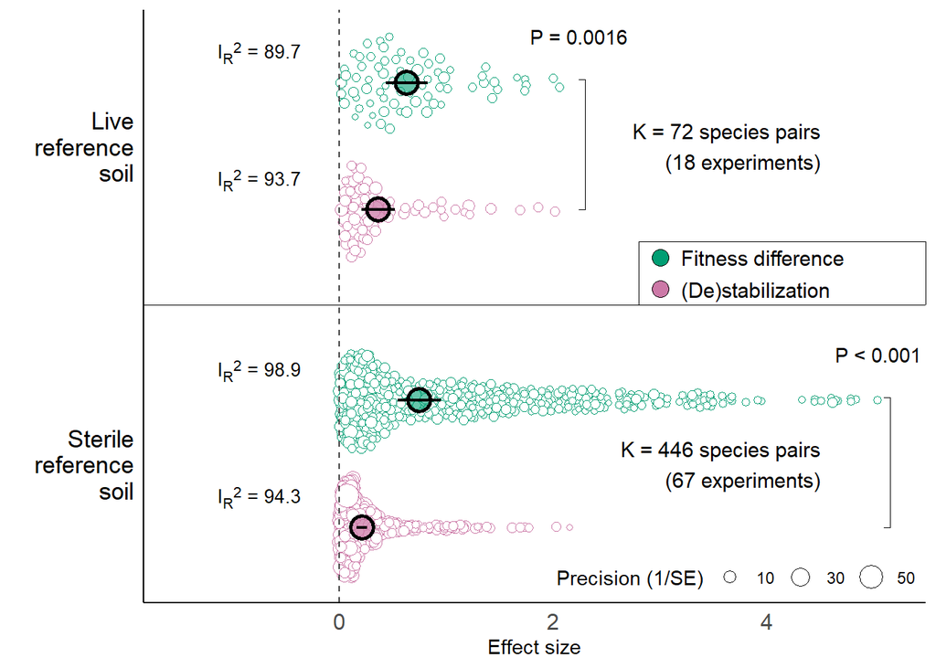

```r
# combine coefficients for models built with live and sterile reference datasets
q1_dfs <- bind_rows(q1.xs.0.5_coefs,
                    q1.lr.0.5_coefs)

# make dataframes to arrange the effectsizes and prediction intervals
q1_dfs <- q1_dfs %>%
  mutate(yval = c(1.2, 0.8, 2.2, 1.8),
         which_source = rep(c("XS", "LR"), each = 2),
         effect_type = rep(c("Fitness difference",
                             "(De)stabilization"), 2),
         I2R = c(I2R_SterileRef, I2R_LiveRef))

# calculating prediction intervals, currently not in fig.3
# (but contains commented code below to include it in the figure)
prediction_intervals <- bind_rows(data.frame(predict.rma(q1.xs.0.5)[1:2,]),
                                  data.frame(predict.rma(q1.lr.0.5)[1:2,])) %>%
  mutate(which_source = rep(c("XS", "LR"), each = 2),
         effect_type = c("(De)stabilization", "Fitness difference", "(De)stabilization", "Fitness difference"))

# combine coefficient dataframe with prediction interval dataframe
q1_dfs <- left_join(x = q1_dfs, y = prediction_intervals,
                    by = c("effect_type", "which_source"))

# add a new column to the long datasets to capture the "scale"
# (1/precision) for each effect size
sterile_ref_long <-
  sterile_ref_long %>%
  mutate(scale = 1/sqrt(var_value),
         yval = ifelse(set == "FD", 1.2,0.8)) %>%
  mutate(effect_type = ifelse(set == "FD", "Fitness difference", "(De)stabilization"))


live_ref_long <-
  live_ref_long %>%
  mutate(scale = 1/sqrt(var_value),
         yval = ifelse(set == "FD", 2.2,1.8)) %>%
  mutate(effect_type = ifelse(set == "FD", "Frequency independent", "Frequency dependent"))

(q1_plot <-
  ggplot(q1_dfs) +
  ggbeeswarm::geom_quasirandom(data = sterile_ref_long,
                               aes(y = absolute_FDSD_effects, x = yval, size = scale, color = effect_type),
                               alpha = 1, pch = 21, fill = "transparent", stroke = .25) +
  ggbeeswarm::geom_quasirandom(data = live_ref_long,
                               aes(y = absolute_FDSD_effects, x = yval, size = scale, color = effect_type),
                               alpha = 1, pch = 21, fill = "transparent", stroke = .25) +
  geom_point(aes(y = beta, x = yval, fill = effect_type),
             size = 5, stroke = 1.5, shape = 21) +
  geom_errorbar(aes(x = yval, ymin = CI_L, ymax = CI_U), width = 0, size = 0.8) +
  # geom_errorbar(aes(x = yval, ymin = pi.lb, ymax = pi.ub), width = 0, size = 0.15) +
  geom_vline(xintercept = 1.5, size = .25) +
  geom_hline(yintercept = 0, linetype = 2, size = .5, color = "grey25") +
  annotate("text", y = 4.5, x = 2, label = paste0("K = ", nrow(live_ref_long)/2,
                                                  " species pairs\n (",length(unique(live_ref_long$Experiment))," experiments)"),
           hjust = 1, size = 4) +
  annotate("text", y = 4.5, x = 1, label = paste0("K = ", nrow(sterile_ref_long)/2,
                                                  " species pairs\n (",length(unique(sterile_ref_long$Experiment))," experiments)"),
           hjust = 1, size = 4) +
  scale_fill_manual(name = "", values = rev(c(alpha("#009E73",0.6), alpha("#CC79A7",0.75)))) +
  scale_color_manual(name = "", values = rev(c("#009E73", "#CC79A7", "#009E73","#CC79A7"))) +
  scale_x_continuous(name = "", breaks = c(1,2), labels = c("Sterile\nreference\nsoil", "Live\nreference\nsoil")) +
  scale_y_continuous(limits = c(-1.5, 5.15), breaks = c(0, 2,4)) +
  scale_size_continuous(name = "Precision (1/SE)", breaks = c(10, 30, 50)) +
  ylab("Effect size") +
  theme_plots() +

  annotate("segment", y = 2.8, yend = Inf, x = c(1.5, 1.7), xend = c(1.5,1.7), size = .25) +
  annotate("segment", y = c(2.8, Inf), yend = c(2.8, Inf), x = 1.5, xend = 1.7, size = .25)  +

  geom_point(aes(y = 3, x = 1.65), size = 4, shape = 21, fill = c("#009E73")) +
  geom_point(aes(y = 3, x = 1.55), size = 4, shape = 21, fill = c("#CC79A7")) +
  annotate("text", y = 3.2, x = 1.65, label = "Fitness difference", hjust = 0, size = 4) +
  annotate("text", y = 3.2, x = 1.55, label = "(De)stabilization", hjust = 0, size = 4) +

  ggtext::geom_richtext(aes(y = -0.75, x = yval,
                            label = paste0("I<sub>R</sub><sup>2</sup> = ", round(I2R, 1))),
                        size = 3.5, vjust = -0.25, label.color = NA) +
  guides(fill = "none", color = "none", text = "none") +

  ggpubr::geom_bracket(xmin = 0.8, xmax = 1.21, y = 5.15,
                       label = "P < 0.001  \n ", tip.length = c(0.01, 0.01)) +
  ggpubr::geom_bracket(xmin = 1.8, xmax = 2.21, y = 2.3,
                       label = "P = 0.0016\n ", tip.length = c(0.01, 0.01)) +

  theme(axis.text.y = element_text(color = "black", size = 13),
        axis.text.x = element_text(size = 12),
        legend.position= c(1, 0),
        legend.direction = "horizontal",
        legend.justification = c(1, 0),
        plot.title.position = "plot",
        plot.title = element_text(face = "bold")) +
  coord_flip())
```

```r
if(save_figures) {
  ggsave("figures/q1_figure.png",q1_plot, bg = "white", width = 6.5, height = 4.5)
  ggsave("figures/q1_figure.pdf",q1_plot, bg = "white", width = 6.5, height = 4.5)
  ggsave("figures/q1_figure.eps",q1_plot, bg = "white", width = 6.5, height = 4.5)
}
```

### Evaluate robustness of results

Next we conducted a series of analyses to evaluate the robustness of the results in Figure 3. Specifically, we conducted moderator analyses to evaluate how experimental methodology affects outcomes, compared the results from our multi-variate analyses to univariate analyses of stabilization/fitness differences, evaluated how results were determined by our assumed value of within-study correlation of stabilzation/fitness differences, and evaluated whether results were especially influenced by particular studies.

#### Moderator analyses (Figure S3)

Next, we explored how experimental moderators affect the outcomes using mixed effect models. To do this we went through our 4/5 moderator variables (for live/sterile references, respectively) and conducted separate meta-analyses for each moderator variable.

#### Live ref soils Moderator analysis

**Inoculation fraction: High/Low**

For our first moderator analysis we can quantify effect sizes for studies that used high vs. low (<=25% inoculation).

```r
# Make columns to help conduct the analyses
live_ref_long <-
  live_ref_long %>%
  mutate(inoc_frac_binary = ifelse(`Fraction inoculum` < 0.2501, "low", "high"),
         set_inoc_frac = paste0(set, "_", inoc_frac_binary),
         set_trainingEnv = paste0(set, "_", `Training environment`),
         set_testingEnv = paste0(set, "_", `Testing environment`),
         set_testingCommunity = paste0(set, "_", `Testing community`))

# # Check which comparisons are possible to make in this dataset:
# table(live_ref$`Training environment`) # 14 pairs in field, 58 in lab
# table(live_ref$`Testing environment`) # 3 pairs in the field, 69 in lab
# table(live_ref$`Testing community`) # 2 pairs population; 15 pairs community, 55 pairs individual
# table(live_ref_long$inoc_frac_binary)/2 # 17 pairs with low, 55 pairs with high
#
# nrow(unique(live_ref_long[which(live_ref_long$`Training environment` == "Field"),"Experiment"]))
# nrow(unique(live_ref_long[which(live_ref_long$`Training environment` == "Lab"),"Experiment"]))
# nrow(unique(live_ref_long[which(live_ref_long$inoc_frac_binary == "low"),"Experiment"]))
# nrow(unique(live_ref_long[which(live_ref_long$inoc_frac_binary == "high"),"Experiment"]))
# nrow(unique(live_ref_long[which(live_ref_long$`Testing community` == "Population"),"Experiment"]))
# nrow(unique(live_ref_long[which(live_ref_long$`Testing community` == "Community"),"Experiment"]))
# nrow(unique(live_ref_long[which(live_ref_long$`Testing community` == "Individual"),"Experiment"]))

# mixed effect model using rma.mv() (wrapper function here is defined above)
q1.lr.inocFrac <- run_metamod(which_df = live_ref_long,
                              which_response_column = "absolute_FDSD_effects",
                              # set(SD/FD) and inoc_frac as fixed effects
                              moderators = " ~ (set_inoc_frac-1)",
                              impute_cov_r = 0.5)
# coef_test(q1.lr.inocFrac, vcov = "CR2") %>% # check if different from zero
#   kable() %>%
#   kable_styling(full_width = F)
conf_int(q1.lr.inocFrac, vcov = "CR2") %>% # take look at the confidence interval
  kable() %>%
  kable_styling(full_width = F)
```

|  | Coef | beta | SE | df | CI_L | CI_U |
| --- | --- | --- | --- | --- | --- | --- |
| set_inoc_fracFD_high | set_inoc_fracFD_high | 0.6447761 | 0.1100202 | 12.054272 | 0.4051824 | 0.8843698 |
| set_inoc_fracFD_low | set_inoc_fracFD_low | 0.4829630 | 0.0590816 | 1.678832 | 0.1759622 | 0.7899639 |
| set_inoc_fracSD_high | set_inoc_fracSD_high | 0.4054537 | 0.0807271 | 11.602875 | 0.2288946 | 0.5820129 |
| set_inoc_fracSD_low | set_inoc_fracSD_low | 0.1870284 | 0.0359641 | 1.680444 | 0.0003673 | 0.3736896 |

Then we can use `wald_test` to evaluate whether the strength of stabilization and fitness differences are significantly different from one another in the two categories.

```r
Wald_test(q1.lr.inocFrac, constraints = constrain_equal(c(1,3)), vcov = "CR2") # Check if FD diff from SD in High inoc
```

```
##  test Fstat df_num df_denom   p_val sig
##   HTZ  10.5      1     9.19 0.00984  **
```

```r
Wald_test(q1.lr.inocFrac, constraints = constrain_equal(c(2,4)), vcov = "CR2") # Check if FD diff from SD in low inoc
```

```
##  test Fstat df_num df_denom p_val sig
##   HTZ  12.7      1     1.26 0.132
```

Over the next few lines we repeat this type of analysis for different moderator variables.

**Conditioning phase environment: Greenhouse/Field**

```r
q1.lr.trainEnv <- run_metamod(which_df = live_ref_long,
                              which_response_column = "absolute_FDSD_effects",
                              moderators = " ~ (set_trainingEnv-1)",
                              impute_cov_r = 0.5)

# coef_test(q1.lr.trainEnv, vcov = "CR2") %>% # check if different from zero
#   kable() %>%
#   kable_styling(full_width = F)
conf_int(q1.lr.trainEnv, vcov = "CR2") %>% # take look at the confidence interval
  kable() %>%
  kable_styling(full_width = F)
```

|  | Coef | beta | SE | df | CI_L | CI_U |
| --- | --- | --- | --- | --- | --- | --- |
| set_trainingEnvFD_Field | set_trainingEnvFD_Field | 0.3760611 | 0.1401516 | 3.579264 | -0.0317825 | 0.7839048 |
| set_trainingEnvFD_Lab | set_trainingEnvFD_Lab | 0.7106848 | 0.1060617 | 9.490630 | 0.4726340 | 0.9487356 |
| set_trainingEnvSD_Field | set_trainingEnvSD_Field | 0.3952396 | 0.0599903 | 3.601112 | 0.2211453 | 0.5693339 |
| set_trainingEnvSD_Lab | set_trainingEnvSD_Lab | 0.3714087 | 0.0951298 | 9.729855 | 0.1586459 | 0.5841715 |

```r
Wald_test(q1.lr.trainEnv, constraints = constrain_equal(c(1,3)), vcov = "CR2") # Field: FD vs SD
```

```
##  test  Fstat df_num df_denom p_val sig
##   HTZ 0.0171      1     2.95 0.904
```

```r
Wald_test(q1.lr.trainEnv, constraints = constrain_equal(c(2,4)), vcov = "CR2") # Lab: FD vs SD
```

```
##  test Fstat df_num df_denom  p_val sig
##   HTZ  57.6      1     5.45 <0.001 ***
```

**Response phase growth type: Individual/Population/Community**

```r
# Testing community ----
q1.lr.testComm <- run_metamod(which_df = live_ref_long,
                              which_response_column = "absolute_FDSD_effects",
                              moderators = " ~ (set_testingCommunity-1)",
                              impute_cov_r = 0.5)
# coef_test(q1.lr.testComm, vcov = "CR2") %>% # check if different from zero
  # kable() %>%
  # kable_styling(full_width = F)
conf_int(q1.lr.testComm, vcov = "CR2") %>% # take look at the confidence interval
  kable() %>%
  kable_styling(full_width = F)
```

|  | Coef | beta | SE | df | CI_L | CI_U |
| --- | --- | --- | --- | --- | --- | --- |
| set_testingCommunityFD_Community | set_testingCommunityFD_Community | 0.5418709 | 0.2002920 | 1.970319 | -0.3324770 | 1.4162188 |
| set_testingCommunityFD_Individual | set_testingCommunityFD_Individual | 0.6726773 | 0.1123367 | 10.190987 | 0.4230098 | 0.9223448 |
| set_testingCommunityFD_Population | set_testingCommunityFD_Population | 0.3552481 | 0.0735266 | 1.000013 | -0.5789660 | 1.2894622 |
| set_testingCommunitySD_Community | set_testingCommunitySD_Community | 0.2430481 | 0.1031686 | 1.940225 | -0.2142171 | 0.7003133 |
| set_testingCommunitySD_Individual | set_testingCommunitySD_Individual | 0.4116234 | 0.0895896 | 9.882843 | 0.2116842 | 0.6115626 |
| set_testingCommunitySD_Population | set_testingCommunitySD_Population | 0.1959575 | 0.1218909 | 1.000043 | -1.3526544 | 1.7445695 |

```r
Wald_test(q1.lr.testComm, constraints = constrain_equal(c(1,4)), vcov = "CR2") # Q1 FD v SD, community
```

```
##  test Fstat df_num df_denom p_val sig
##   HTZ  1.31      1     1.86 0.379
```

```r
Wald_test(q1.lr.testComm, constraints = constrain_equal(c(2,5)), vcov = "CR2") # Q1 FD v SD, individual
```

```
##  test Fstat df_num df_denom   p_val sig
##   HTZ  20.4      1     5.94 0.00412  **
```

```r
Wald_test(q1.lr.testComm, constraints = constrain_equal(c(3,6)), vcov = "CR2") # Q1 FD v SD, population
```

```
##  test Fstat df_num df_denom p_val sig
##   HTZ  10.6      1     1.01 0.189
```

Next, we put all this information together to make a plot of stabilization/fitness differences across different moderator variables for pairs with live soil reference.

[figure not shown]

```r
# combine coefficients from models built with the above moderators respectively
q1.lr.coefs.plot <- bind_rows(conf_int(q1.lr.0.5, vcov = "CR2"),
                              conf_int(q1.lr.trainEnv, vcov = "CR2"),
                              conf_int(q1.lr.inocFrac, vcov =  "CR2"),
                              conf_int(q1.lr.testComm, vcov = "CR2")) %>%
  data.frame() %>%
  rownames_to_column("which")
q1.lr.coefs.plot <-
  q1.lr.coefs.plot %>%
  mutate(yval = rev(c(0.9,1.4,1.9, 1.1,1.6,2.1,
                      2.4,2.9,     2.6,3.1,
                      3.4,3.9,     3.6,4.1,
                      4.4,4.6)),
         set = c("FD", "SD", "FD", "FD", "SD", "SD","FD", "FD", "SD", "SD",
                 "FD", "FD", "FD", "SD", "SD", "SD"),
         set = ifelse(set == "FD", "Fitness difference", "(De)stabilization"))


# making a moderator plot
q1.mods.lr.plot <-
  ggplot(q1.lr.coefs.plot, aes(y = beta, x = yval)) +
  geom_ribbon(aes(x = seq(0.75, 2.25, length.out = 16), ymin = -Inf, ymax = Inf), fill = "grey90") +
  geom_ribbon(aes(x = seq(3.25, 4.25, length.out = 16), ymin = -Inf, ymax = Inf), fill = "grey90") +

  geom_point(size = 4, aes(fill = set), shape = 21) +
  geom_errorbar(aes(ymin = CI_L, ymax = CI_U), width = 0, size = .4) +
  geom_vline(xintercept = c(2.25, 3.25, 4.25), size = 0.25) +
  geom_vline(xintercept = c(1.25, 1.75, 2.75, 3.75), size = 0.25, linetype = 2) +
  scale_fill_manual(name = "", values = c("#CC79A7", "#009E73")) +
  scale_x_continuous(breaks = c(1.5, 2.75, 3.75, 4.5),
                     expand = c(0,0), limits = c(0.75, 4.75),

                     labels = c("Response\nphase\ngrowth\ntype",
                                "Inoculation\nFraction",
                                "Training\nphase\nlocation",
                                "Overall")) +
  annotate("text", y = -Inf, x = c(1.25, 1.75, 2.25, 2.75, 3.25, 3.75, 4.25, Inf),
           label = c(
             ' Community (15 pairs / 3 experiments)',
             ' Individual (55 pairs / 13 experiments)',
             ' Population (2 pairs / 2 experiments)',
             ' Low (<25%) (17 pairs / 3 experiments)',
             ' High (>25%) (55 pairs / 15 experiments)',
             ' Greenhouse (58 pairs / 15 experiments)',
             ' Field (14 pairs / 3 experiments)',
             ' All pairs (72 pairs / 18 experiments)'),
           hjust = 0, vjust = 1.5,
           color = "grey25", fontface = "italic", size = 3.5) +
  xlab("") +
  ylab("Effect size") +
  theme_plots() +
  theme(axis.text.y = element_text(size = 11, color = "black"),
        legend.position = "bottom",
        plot.title = element_text(face = "bold"),
        plot.title.position = "plot") +
    ggpubr::geom_bracket(xmin = c(1.4, 2.9, 3.4, 4.4),
                         xmax = c(1.6, 3.1, 3.6, 4.6),
                         y.position = 1.25,
                         label = c("**", "***","**", "**"), tip.length = c(0.01, 0.01),
                         vjust = 0.5) +
  coord_flip() +
  labs(title = "(A) Live soil reference moderator analysis")

q1.mods.lr.plot
```

#### Sterile soil moderator analysis

We now repeat the code above, but for pairs with sterile soils as reference. These analyses often take a long time, so we have saved the output from the code below in `code/saved_results` and import those files into the analysis.

We first cleanup data by binning data for frac_inoc categories (low:<=0.25) and binning minority sterilization methods into “other” category.

```r
# first cleanup data by binning data for frac_inoc categories (low:<=0.25)
# and binning minority sterilization methods into "other" category
sterile_ref_long <-
  sterile_ref_long %>%
  mutate(`Training environment` = ifelse(`Training environment` == "LabField", "Lab", `Training environment`)) %>%
  mutate(inoc_frac_binary = ifelse(`Fraction inoculum` <= 0.25, "low", "high"),
         set_inoc_frac = paste0(set, "_", inoc_frac_binary),
         set_trainingEnv = paste0(set, "_", `Training environment`),
         set_testingEnv = paste0(set, "_", `Testing environment`),
         set_controlType = paste0(set, "_", control_type),
         Study_sterilization_method = ifelse(Study_sterilization_method %in%
                                               c("not specified", "pasteurization", "steam-pasteurization", "steaming"),
                                             "other",
                                             Study_sterilization_method),
         set_sterileMethod = paste0(set, "_", Study_sterilization_method),
         set_communityType = paste0(set, "_", `Testing community`))
```

**Inoculation fraction: High/Low**

```r
# directly sourcing previously-saved outcome to save time
# running the model code may take ~10 min
# q1.xs.inocFrac <- run_metamod(which_df = sterile_ref_long,
#                               which_response_column = "absolute_FDSD_effects",
#                               moderators = " ~ (set_inoc_frac-1)",
#                               impute_cov_r = 0.5)
# saveRDS(q1.xs.inocFrac, "code/saved_results/q1.xs.inocFrac")
q1.xs.inocFrac <- readRDS("code/saved_results/q1.xs.inocFrac")

# coef_test(q1.xs.inocFrac, vcov = "CR2") # check if different from zero
conf_int(q1.xs.inocFrac, vcov = "CR2") %>% # take look at the confidence interval
  kable() %>%
  kable_styling(full_width = F)
```

|  | Coef | beta | SE | df | CI_L | CI_U |
| --- | --- | --- | --- | --- | --- | --- |
| set_inoc_fracFD_high | set_inoc_fracFD_high | 0.7434680 | 0.1284906 | 17.83454 | 0.4733395 | 1.0135964 |
| set_inoc_fracFD_low | set_inoc_fracFD_low | 0.7476425 | 0.1362295 | 33.69125 | 0.4706974 | 1.0245875 |
| set_inoc_fracSD_high | set_inoc_fracSD_high | 0.2670052 | 0.0651052 | 18.25240 | 0.1303597 | 0.4036507 |
| set_inoc_fracSD_low | set_inoc_fracSD_low | 0.1857668 | 0.0172844 | 34.95795 | 0.1506761 | 0.2208574 |

```r
Wald_test(q1.xs.inocFrac, constraints = constrain_equal(c(1,3)), vcov = "CR2") # high: FD vs SD
```

```
##  test Fstat df_num df_denom   p_val sig
##   HTZ  13.9      1     17.3 0.00166  **
```

```r
Wald_test(q1.xs.inocFrac, constraints = constrain_equal(c(2,4)), vcov = "CR2") # Low: FD vs SD
```

```
##  test Fstat df_num df_denom  p_val sig
##   HTZ  20.4      1     32.5 <0.001 ***
```

**Conditioning phase environment: Greenhouse/Field**

```r
# Training environment -------
# directly sourcing previously-saved outcome to save time
# running the model code may take ~10 min
# q1.xs.trainEnv <- run_metamod(which_df = sterile_ref_long,
#                               which_response_column = "absolute_FDSD_effects",
#                               moderators = " ~ (set_trainingEnv-1)",
#                               impute_cov_r = 0.5)
# saveRDS(q1.xs.trainEnv, "code/saved_results/q1.xs.trainEnv")
q1.xs.trainEnv <- readRDS("code/saved_results/q1.xs.trainEnv")

# coef_test(q1.xs.trainEnv, vcov = "CR2") # check if different from zero
conf_int(q1.xs.trainEnv, vcov = "CR2") %>% # take look at the confidence interval
  kable() %>%
  kable_styling(full_width = F)
```

|  | Coef | beta | SE | df | CI_L | CI_U |
| --- | --- | --- | --- | --- | --- | --- |
| set_trainingEnvFD_Field | set_trainingEnvFD_Field | 0.6407833 | 0.0891627 | 34.36207 | 0.4596531 | 0.8219135 |
| set_trainingEnvFD_Lab | set_trainingEnvFD_Lab | 0.9114088 | 0.2018883 | 17.60269 | 0.4865700 | 1.3362476 |
| set_trainingEnvSD_Field | set_trainingEnvSD_Field | 0.1967454 | 0.0280773 | 36.00329 | 0.1398021 | 0.2536887 |
| set_trainingEnvSD_Lab | set_trainingEnvSD_Lab | 0.2384962 | 0.0444441 | 18.75195 | 0.1453902 | 0.3316022 |

```r
Wald_test(q1.xs.trainEnv, constraints = constrain_equal(1:3), vcov = "CR2") # Field: FD vs SD
```

```
##  test Fstat df_num df_denom  p_val sig
##   HTZ  24.6      2       35 <0.001 ***
```

```r
Wald_test(q1.xs.trainEnv, constraints = constrain_equal(2:4), vcov = "CR2") # Lab: FD vs SD
```

```
##  test Fstat df_num df_denom   p_val sig
##   HTZ  5.95      2     25.4 0.00757  **
```

**Response phase reference soil type environment: CmS/CS/FS/GS**

- Recall that CmS = mixed conditioned soils; CS = sterilized conditioned soil; FS = sterilized field soil; GS = sterilized greenhouse soil

```r
# Control type ---------
# directly sourcing previously-saved outcome to save time
# running the model code may take ~5 min
# q1.xs.controlType <- run_metamod(which_df = sterile_ref_long,
#                                  which_response_column = "absolute_FDSD_effects",
#                                  moderators = " ~ (set_controlType-1)",
#                                  impute_cov_r = 0.5)
# saveRDS(q1.xs.controlType, "code/saved_results/q1.xs.controlType")
q1.xs.controlType <- readRDS("code/saved_results/q1.xs.controlType")

# coef_test(q1.xs.controlType, vcov = "CR2") # check if different from zero
conf_int(q1.xs.controlType, vcov = "CR2") %>% # take look at the confidence interval
  kable() %>%
  kable_styling(full_width = F)
```

|  | Coef | beta | SE | df | CI_L | CI_U |
| --- | --- | --- | --- | --- | --- | --- |
| set_controlTypeFD_CmS | set_controlTypeFD_CmS | 0.2575516 | 0.0552553 | 1.944070 | 0.0131309 | 0.5019723 |
| set_controlTypeFD_CS | set_controlTypeFD_CS | 0.6006857 | 0.1069559 | 25.887008 | 0.3807880 | 0.8205834 |
| set_controlTypeFD_FS | set_controlTypeFD_FS | 0.7496226 | 0.1725701 | 6.562040 | 0.3359728 | 1.1632725 |
| set_controlTypeFD_GS | set_controlTypeFD_GS | 1.4579523 | 0.1707753 | 9.477151 | 1.0745765 | 1.8413281 |
| set_controlTypeSD_CmS | set_controlTypeSD_CmS | 0.4365872 | 0.2706576 | 1.991339 | -0.7328256 | 1.6060001 |
| set_controlTypeSD_CS | set_controlTypeSD_CS | 0.1703291 | 0.0270217 | 32.015169 | 0.1152887 | 0.2253696 |
| set_controlTypeSD_FS | set_controlTypeSD_FS | 0.3016669 | 0.0470920 | 6.175626 | 0.1872267 | 0.4161071 |
| set_controlTypeSD_GS | set_controlTypeSD_GS | 0.2222954 | 0.0303956 | 11.619813 | 0.1558279 | 0.2887628 |

```r
Wald_test(q1.xs.controlType, constraints = constrain_equal(c(1,5)), vcov = "CR2") # CmS: Fd vs SD
```

```
##  test Fstat df_num df_denom p_val sig
##   HTZ 0.422      1     1.92 0.585
```

```r
Wald_test(q1.xs.controlType, constraints = constrain_equal(c(2,6)), vcov = "CR2") # CS: FD vs SD
```

```
##  test Fstat df_num df_denom  p_val sig
##   HTZ  22.2      1       23 <0.001 ***
```

```r
Wald_test(q1.xs.controlType, constraints = constrain_equal(c(3,7)), vcov = "CR2") # FS: FD vs SD
```

```
##  test Fstat df_num df_denom  p_val sig
##   HTZ  5.37      1     6.16 0.0586   .
```

```r
Wald_test(q1.xs.controlType, constraints = constrain_equal(c(4,8)), vcov = "CR2") # GS: FD vs SD
```

```
##  test Fstat df_num df_denom  p_val sig
##   HTZ  72.8      1     8.26 <0.001 ***
```

**Sterilization method: Autoclaving, Gamma Radiation, Heating, or Other**

```r
# Sterilization method ---------
# directly sourcing previously-saved outcome to save time
# running the model code may take ~5 min
# q1.xs.sterileMethod <- run_metamod(which_df = sterile_ref_long,
#                               which_response_column = "absolute_FDSD_effects",
#                               moderators = " ~ (set_sterileMethod-1)",
#                               impute_cov_r = 0.5)
# saveRDS(q1.xs.sterileMethod, "code/saved_results/q1.xs.sterileMethod")
q1.xs.sterileMethod <- readRDS("code/saved_results/q1.xs.sterileMethod")

# coef_test(q1.xs.sterileMethod, vcov = "CR2") # check if different from zero
conf_int(q1.xs.sterileMethod, vcov = "CR2") %>% # take look at the confidence interval
  kable() %>%
  kable_styling(full_width = F)
```

|  | Coef | beta | SE | df | CI_L | CI_U |
| --- | --- | --- | --- | --- | --- | --- |
| set_sterileMethodFD_autoclaving | set_sterileMethodFD_autoclaving | 0.4323789 | 0.0994516 | 20.065028 | 0.2249697 | 0.6397882 |
| set_sterileMethodFD_gamma irradiation | set_sterileMethodFD_gamma irradiation | 1.0147852 | 0.1665735 | 7.636759 | 0.6274625 | 1.4021080 |
| set_sterileMethodFD_heating | set_sterileMethodFD_heating | 1.9391413 | 0.0205284 | 3.994673 | 1.8821153 | 1.9961672 |
| set_sterileMethodFD_other | set_sterileMethodFD_other | 0.3852328 | 0.1140017 | 8.180240 | 0.1233493 | 0.6471164 |
| set_sterileMethodSD_autoclaving | set_sterileMethodSD_autoclaving | 0.1499915 | 0.0165809 | 28.988289 | 0.1160792 | 0.1839039 |
| set_sterileMethodSD_gamma irradiation | set_sterileMethodSD_gamma irradiation | 0.3179508 | 0.0856622 | 10.503562 | 0.1283166 | 0.5075851 |
| set_sterileMethodSD_heating | set_sterileMethodSD_heating | 0.3166535 | 0.0100848 | 3.997874 | 0.2886478 | 0.3446591 |
| set_sterileMethodSD_other | set_sterileMethodSD_other | 0.1959404 | 0.0498763 | 8.629237 | 0.0823690 | 0.3095119 |

```r
Wald_test(q1.xs.sterileMethod, constraints = constrain_equal(c(1,5)), vcov = "CR2") # Autoclaving: FD vs SD
```

```
##  test Fstat df_num df_denom   p_val sig
##   HTZ  9.09      1     19.6 0.00697  **
```

```r
Wald_test(q1.xs.sterileMethod, constraints = constrain_equal(c(2,6)), vcov = "CR2") # Gamma irradiation: FD vs SD
```

```
##  test Fstat df_num df_denom   p_val sig
##   HTZ  19.2      1      7.4 0.00282  **
```

```r
Wald_test(q1.xs.sterileMethod, constraints = constrain_equal(c(3,7)), vcov = "CR2") # Heating: FD vs SD
```

```
##  test Fstat df_num df_denom  p_val sig
##   HTZ  8084      1     3.99 <0.001 ***
```

```r
Wald_test(q1.xs.sterileMethod, constraints = constrain_equal(c(4,8)), vcov = "CR2") # Other: FD vs SD
```

```
##  test Fstat df_num df_denom  p_val sig
##   HTZ  3.98      1     8.12 0.0806   .
```

**Response phase growth type: Individual/Population/Community**

```r
# Community type ---------
# directly sourcing previously-saved outcome to save time
# running the model code may take ~5 min
# q1.xs.communityType <- run_metamod(which_df = sterile_ref_long,
#                                    which_response_column = "absolute_FDSD_effects",
#                                    moderators = " ~ (set_communityType-1)",
#                                    impute_cov_r = 0.5)
# saveRDS(q1.xs.communityType, "code/saved_results/q1.xs.communityType")
q1.xs.communityType <- readRDS("code/saved_results/q1.xs.communityType")

# coef_test(q1.xs.communityType, vcov = "CR2") # check if different from zero
conf_int(q1.xs.communityType, vcov = "CR2") %>% # take look at the confidence interval
  kable() %>%
  kable_styling(full_width = F)
```

|  | Coef | beta | SE | df | CI_L | CI_U |
| --- | --- | --- | --- | --- | --- | --- |
| set_communityTypeFD_Community | set_communityTypeFD_Community | 1.8341309 | 0.0615156 | 6.089070 | 1.6841398 | 1.9841220 |
| set_communityTypeFD_Individual | set_communityTypeFD_Individual | 0.5261654 | 0.0876983 | 24.511765 | 0.3453647 | 0.7069661 |
| set_communityTypeFD_Population | set_communityTypeFD_Population | 0.7921600 | 0.3486605 | 2.859651 | -0.3488865 | 1.9332065 |
| set_communityTypeSD_Community | set_communityTypeSD_Community | 0.3859826 | 0.0476435 | 8.219688 | 0.2766254 | 0.4953397 |
| set_communityTypeSD_Individual | set_communityTypeSD_Individual | 0.1834898 | 0.0299204 | 37.119545 | 0.1228719 | 0.2441077 |
| set_communityTypeSD_Population | set_communityTypeSD_Population | 0.1523392 | 0.0214212 | 5.900417 | 0.0997082 | 0.2049702 |

```r
Wald_test(q1.xs.communityType, constraints = constrain_equal(1:2), vcov = "CR2")
```

```
##  test Fstat df_num df_denom  p_val sig
##   HTZ   149      1     13.8 <0.001 ***
```

```r
Wald_test(q1.xs.communityType, constraints = constrain_equal(3:4), vcov = "CR2")
```

```
##  test Fstat df_num df_denom p_val sig
##   HTZ  1.33      1     3.22 0.327
```

```r
Wald_test(q1.xs.communityType, constraints = constrain_equal(c(1,4)), vcov = "CR2")
```

```
##  test Fstat df_num df_denom  p_val sig
##   HTZ   300      1     6.48 <0.001 ***
```

```r
Wald_test(q1.xs.communityType, constraints = constrain_equal(c(2,5)), vcov = "CR2")
```

```
##  test Fstat df_num df_denom  p_val sig
##   HTZ  15.7      1     26.1 <0.001 ***
```

```r
Wald_test(q1.xs.communityType, constraints = constrain_equal(c(3,6)), vcov = "CR2")
```

```
##  test Fstat df_num df_denom p_val sig
##   HTZ  3.61      1     3.13  0.15
```

```r
# this is the wald test for SD vs. FD in the entire sterile reference dataset:
Wald_test(q1.xs.0.5, constraints = constrain_equal(c(1,2)), vcov = "CR2")
```

```
##  test Fstat df_num df_denom  p_val sig
##   HTZ  33.1      1     50.7 <0.001 ***
```

**Now, put it all together into a plot**

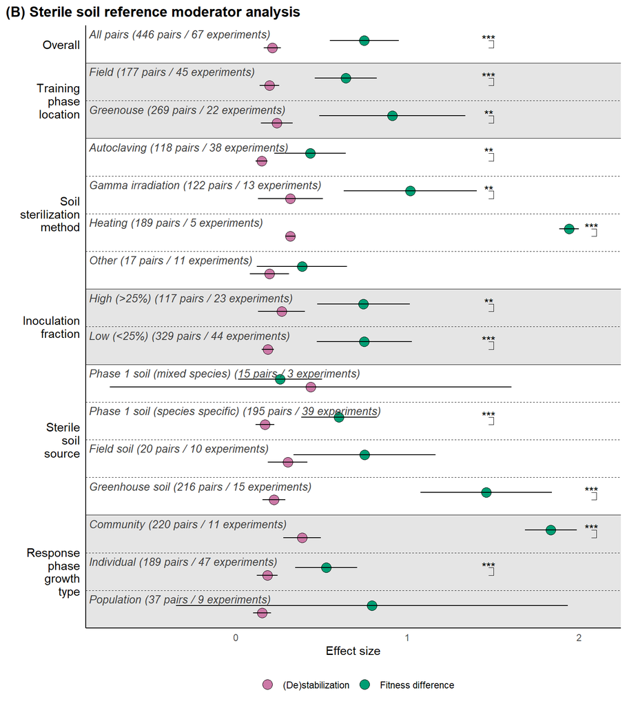

```r
q1.xs.coefs.plot <- bind_rows(conf_int(q1.xs.0.5, vcov = "CR2"),
                              conf_int(q1.xs.trainEnv, vcov = "CR2"),
                              conf_int(q1.xs.sterileMethod, vcov = "CR2"),
                              conf_int(q1.xs.inocFrac, vcov = "CR2"),
                              conf_int(q1.xs.controlType, vcov = "CR2"),
                              conf_int(q1.xs.communityType, vcov = "CR2")) %>%
  data.frame() %>%
  rownames_to_column("which")
q1.xs.coefs.plot <-
  q1.xs.coefs.plot %>%
  mutate(yval = rev(c(c(0.9,1.4,1.9)+0.05, c(1.1,1.6,2.1)-0.05, # Community type
                      c(2.4,2.9,3.4,3.9)+0.05, c(2.6,3.1,3.6,4.1)-0.05, # Control type
                      c(4.4,4.9)+0.05, c(4.6,5.1)-0.05, # Inoculation high/low
                      c(5.4,5.9,6.4,6.9)+0.05, c(5.6,6.1,6.6,7.1)-0.05, # Sterile method
                      c(7.4,7.9)+0.05, c(7.6,8.1)-0.05, # Training Environment
                      8.4+0.05,8.6-0.05) # Overall
                    ),
         set = ifelse(stringr::str_detect(which, "FD"), "FD", "SD"),
         set = ifelse(set == "FD", "Fitness difference", "(De)stabilization"))


q1.mods.xs.plot <-
  ggplot(q1.xs.coefs.plot, aes(y = beta, x = yval)) +
  coord_flip() +
  geom_ribbon(aes(x = seq(0.75, 2.25, length.out = 32), ymin = -Inf, ymax = Inf), fill = "grey90") +
  geom_ribbon(aes(x = seq(4.25, 5.25, length.out = 32), ymin = -Inf, ymax = Inf), fill = "grey90") +
  geom_ribbon(aes(x = seq(7.25, 8.25, length.out = 32), ymin = -Inf, ymax = Inf), fill = "grey90") +
  geom_point(size = 4, aes(fill = set), shape = 21) +
  geom_errorbar(aes(ymin = CI_L, ymax = CI_U), width = 0, size = .4) +
  geom_vline(xintercept = c(2.25, 4.25, 5.25, 7.25, 8.25), size = 0.25) +
  geom_vline(xintercept = c(1.25, 1.75, 2.75, 3.25, 3.75, 4.75,  5.75, 6.25, 6.75,7.75),
             size = 0.25, linetype = 2) +
  scale_fill_manual(name = "", values = c("#CC79A7", "#009E73")) +
  scale_x_continuous(breaks = c(1.5, 3.25, 4.75, 6.25, 7.75, 8.5),
                     expand = c(0,0), limits = c(0.75, 8.75),
                     labels = c("Response\nphase\ngrowth\ntype",
                                "Sterile\nsoil\nsource",
                                "Inoculation\nfraction",
                                "Soil\nsterilization\nmethod",
                                "Training\nphase\nlocation",
                                "Overall")) +
  annotate("text", y = -Inf, x = c(1.25, 1.75, 2.25, 2.75,
                                   3.25, 3.75, 4.25,
                                   4.75, 5.25, 5.75, 6.25,
                                   6.75,7.25, 7.75,8.25, Inf),
           label = c(
             ' Population (37 pairs / 9 experiments)',
             ' Individual (189 pairs / 47 experiments)',
             ' Community (220 pairs / 11 experiments)',
             ' Greenhouse soil (216 pairs / 15 experiments)',
             ' Field soil (20 pairs / 10 experiments)',
             ' Phase 1 soil (species specific) (195 pairs / 39 experiments)',
             ' Phase 1 soil (mixed species) (15 pairs / 3 experiments)',
             ' Low (<25%) (329 pairs / 44 experiments)',
             ' High (>25%) (117 pairs / 23 experiments)',
             ' Other (17 pairs / 11 experiments)',
             ' Heating (189 pairs / 5 experiments)',
             ' Gamma irradiation (122 pairs / 13 experiments)',
             ' Autoclaving (118 pairs / 38 experiments)',
             ' Greenouse (269 pairs / 22 experiments)',
             ' Field (177 pairs / 45 experiments)',
             ' All pairs (446 pairs / 67 experiments)'
             ),
           hjust = 0, vjust = 1.5,
           color = "grey25", fontface = "italic", size = 3.5) +
  xlab("") +
  ylab("Effect size") +
  theme_plots() +
  theme(axis.text.y = element_text(size = 11, color = "black"),
        legend.position = "bottom",
        plot.title = element_text(face = "bold"),
        plot.title.position = "plot") +
    ggpubr::geom_bracket(xmin = c(8.45, 7.95,7.45, 7.05,6.55,6.05, 4.95,4.45, 3.45,2.45, 1.95,1.45),
                         xmax = c(8.55, 8.05,7.55, 6.95,6.45,5.95, 5.05,4.55, 3.55,2.55, 2.05,1.55),
                         y.position = c(1.5,1.5,1.5,1.5,1.5, 2.1, 1.5,1.5,1.5, 2.1, 2.1, 1.5),
                         tip.length = c(0.01,0.01),
                         vjust = 1,
                         label = c("***", "***", "**", "**", "**", "***", "**", "***", "***", "***", "***", "***")) +
  labs(title = "(B) Sterile soil reference moderator analysis")

q1.mods.xs.plot
```

```r
# table(sterile_ref_long$`Training environment`) # 177 pairs in field, 235 in lab, 34 in LabField
# table(sterile_ref$`Testing environment`) # 2 pairs in the field, 444 in lab
# table(sterile_ref_long$inoc_frac_binary)/2 # 117 pairs with low, 329 pairs with high
# table(sterile_ref_long$`Testing community`)/2 # 440 community, 378 individual, 74 population
# table(sterile_ref_long$Study_sterilization_method)/2 # 236 pairs autoclave, 244 pairs gamma irradiation, 378 pairs heating, 34 pairs 'other'
# table(sterile_ref$control_type) # 15 CmS, 195 CS, 20 FS, 216 GS
# nrow(sterile_ref)
#
# nrow(unique(sterile_ref_long[which(sterile_ref_long$control_type == "CmS"),"Experiment"]))
# nrow(unique(sterile_ref_long[which(sterile_ref_long$control_type == "CS"),"Experiment"]))
# nrow(unique(sterile_ref_long[which(sterile_ref_long$control_type == "GS"),"Experiment"]))
# nrow(unique(sterile_ref_long[which(sterile_ref_long$control_type == "FS"),"Experiment"]))
#
# nrow(unique(sterile_ref_long[which(sterile_ref_long$`Training environment` == "Field"),"Experiment"]))
# nrow(unique(sterile_ref_long[which(sterile_ref_long$`Training environment` == "Lab"),"Experiment"]))
# nrow(unique(sterile_ref_long[which(sterile_ref_long$inoc_frac_binary == "low"),"Experiment"]))
# nrow(unique(sterile_ref_long[which(sterile_ref_long$inoc_frac_binary == "high"),"Experiment"]))
#
# nrow(unique(sterile_ref_long[which(sterile_ref_long$`Testing community` == "Population"),"Experiment"]))
# nrow(unique(sterile_ref_long[which(sterile_ref_long$`Testing community` == "Individual"),"Experiment"]))
# nrow(unique(sterile_ref_long[which(sterile_ref_long$`Testing community` == "Community"),"Experiment"]))
#
# nrow(unique(sterile_ref_long[which(sterile_ref_long$Study_sterilization_method == "heating"),"Experiment"]))
# nrow(unique(sterile_ref_long[which(sterile_ref_long$Study_sterilization_method == "gamma irradiation"),"Experiment"]))
# nrow(unique(sterile_ref_long[which(sterile_ref_long$Study_sterilization_method == "autoclaving"),"Experiment"]))
# nrow(unique(sterile_ref_long[which(sterile_ref_long$Study_sterilization_method == "other"),"Experiment"]))
```

*For the supplement of the main paper, we put these plots together into one multipanel figure (Figure S.3; expand following code block for details).*

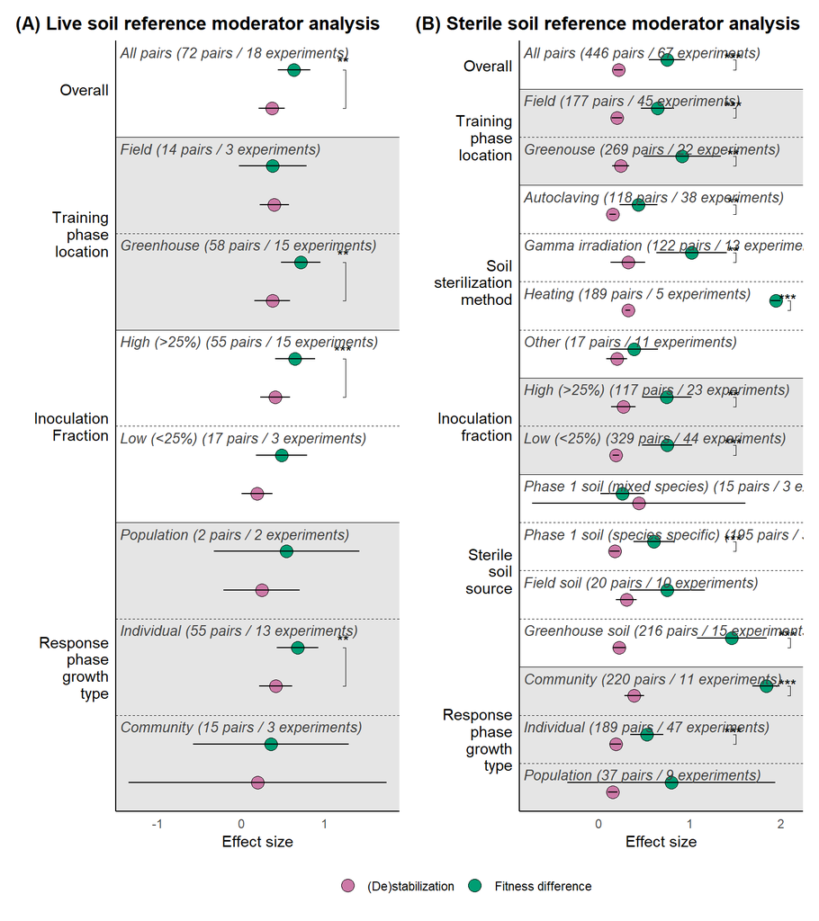

```r
# combine plots of the two datasets side by side
q1_mods_plot <-
  q1.mods.lr.plot + q1.mods.xs.plot +
  plot_layout(guides = "collect") &
  theme(legend.position = "bottom")
q1_mods_plot
```

```r
if(save_figures) {
  ggsave("figures/q1_mods_plot.png", q1_mods_plot,
         bg = "transparent", height = 10, width = 10)
}
```

#### Fig. S.4: Univariate version of the Q1 models

To test robustness of our results, we ran univariate models of just SD or FD, and compared their magnitudes to the results of the multivariate analyses reported in Fig. 3.  
*Click on `code` to see code for univariate analyses*.

```r
# live reference dataset
q1.lr.univariate.fd <- rma.mv(yi = absolute_FDSD_effects, V = var_value,
                              random = ~ 1|Experiment,
                              # only feed in data of the relevant effect size
                              data = live_ref_long %>% filter(set == "FD"))

q1.lr.univariate.sd <- rma.mv(yi = absolute_FDSD_effects, V = var_value,
                              random = ~ 1|Experiment,
                              data = live_ref_long %>% filter(set == "SD"))

# sterile reference dataset
q1.xs.univariate.fd <- rma.mv(yi = absolute_FDSD_effects, V = var_value,
                              random = ~ 1|Experiment,
                              data = sterile_ref_long %>% filter(set == "FD"))
q1.xs.univariate.sd <- rma.mv(yi = absolute_FDSD_effects, V = var_value,
                              random = ~ 1|Experiment,
                              data = sterile_ref_long %>% filter(set == "SD"))


# combine model coefficients for visual comparison
q1_multi_v_uni <-
  bind_rows(
  data.frame(conf_int(q1.xs.0.5, "CR2")),
  data.frame(conf_int(q1.xs.univariate.fd, "CR2")),
  data.frame(conf_int(q1.xs.univariate.sd, "CR2")),
  data.frame(conf_int(q1.lr.0.5, "CR2")),
  data.frame(conf_int(q1.lr.univariate.fd, "CR2")),
  data.frame(conf_int(q1.lr.univariate.sd, "CR2"))

) %>%
  mutate(which_analysis = rep(c("Multivariate", "Multivariate", "Univariate", "Univariate"),2),
         which_metric = rep(c("Fitness difference", "(De)stabilization"), 4),
         which_ref = c("Sterile", "Sterile", "Sterile", "Sterile", "Live", "Live", "Live", "Live"),
         yval = c(1.25, 0.85, 1.15, 0.75,
                  2.25, 1.85, 2.15, 1.75))

q1_multi_v_uni %>%
  as_tibble() %>%
  kable %>%
  kable_styling(full_width = F)
```

| Coef | beta | SE | df | CI_L | CI_U | which_analysis | which_metric | which_ref | yval |
| --- | --- | --- | --- | --- | --- | --- | --- | --- | --- |
| setFD | 0.7481240 | 0.0998507 | 52.28617 | 0.5477851 | 0.9484630 | Multivariate | Fitness difference | Sterile | 1.25 |
| setSD | 0.2129724 | 0.0245917 | 54.80088 | 0.1636855 | 0.2622593 | Multivariate | (De)stabilization | Sterile | 0.85 |
| intrcpt | 0.6118938 | 0.0755687 | 64.60269 | 0.4609551 | 0.7628325 | Univariate | Fitness difference | Sterile | 1.15 |
| intrcpt | 0.2010285 | 0.0224690 | 58.74263 | 0.1560641 | 0.2459929 | Univariate | (De)stabilization | Sterile | 0.75 |
| setFD | 0.6308654 | 0.0909003 | 14.07147 | 0.4359965 | 0.8257343 | Multivariate | Fitness difference | Live | 2.25 |
| setSD | 0.3638120 | 0.0721101 | 13.98696 | 0.2091377 | 0.5184862 | Multivariate | (De)stabilization | Live | 1.85 |
| intrcpt | 0.5965602 | 0.0977646 | 15.64835 | 0.3889292 | 0.8041911 | Univariate | Fitness difference | Live | 2.15 |
| intrcpt | 0.3649092 | 0.0631866 | 15.63165 | 0.2307026 | 0.4991157 | Univariate | (De)stabilization | Live | 1.75 |

We can visualize these results in a figure:

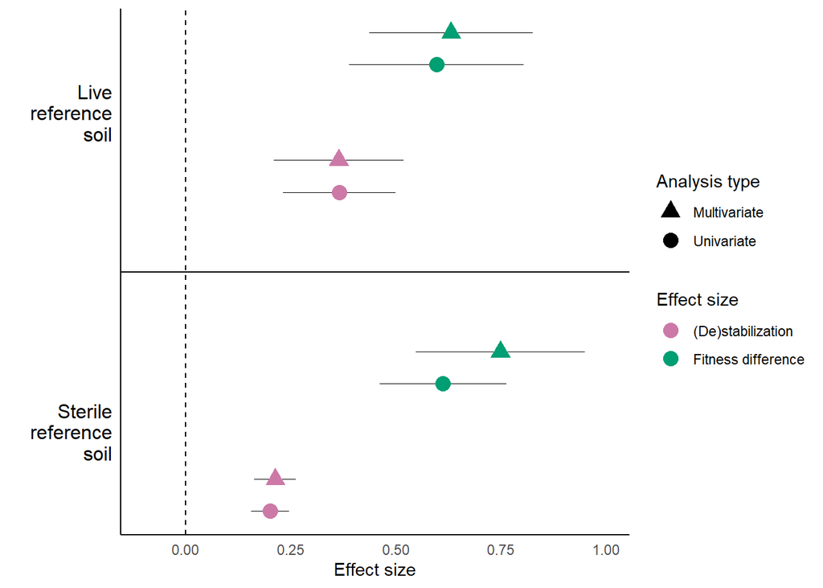

```r
q1_multi_v_uni_plot <-
  ggplot(q1_multi_v_uni) +
  # facet_wrap(.~which_ref) +
  geom_errorbarh(aes(xmin = CI_L, xmax = CI_U, y = yval), height = 0, size = 0.25) +
  geom_point(aes(x = beta, y = yval, color = which_metric, shape = which_analysis), size = 4) +
  scale_color_manual(name = "Effect size", values = c("#CC79A7", "#009E73")) +
  scale_shape_manual(name = "Analysis type", values = c(17,19)) +
  ylab("") + xlab("Effect size") +
  scale_y_continuous(breaks = c(1,2), labels = c("Sterile\nreference\nsoil", "Live\nreference\nsoil")) +
  scale_x_continuous(limits = c(-0.1, 1)) +
  geom_hline(yintercept = 1.5) +
    geom_vline(xintercept = 0, linetype = 2) +

  theme_plots() +
  theme(axis.text.y = element_text(size = 12, color = "black"),
        # legend.position = "top",
        legend.direction = "vertical")

q1_multi_v_uni_plot
```

```r
if(save_figures) {
  ggsave("figures/q1_Uni_Vs_Multivariate.png",
         q1_multi_v_uni_plot, height = 3, width = 6)
}
```

#### Fig. S.5: Evaluate sensitivity of Q1 multivariate models to the imputed value of within-experient correlation

Next we ran models as in the main text, but we impute covariance matrices with assumed within-experiment (de)stabilization-fitness difference correlations of -0.5, 0.1, or 0.9. (The main text models are run with assumed correlations of 0.5.). *Click on `code` for details*.

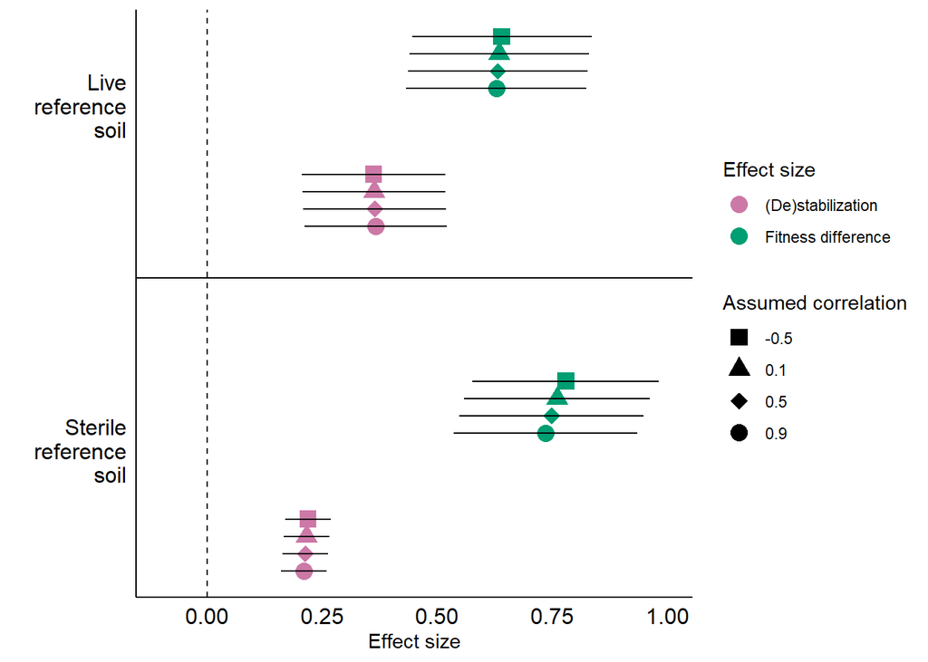

```r
# the three models below uses var-covar matrix imputed with r = 0.1, 0.9, -0.5

# live reference dataset:
q1.lr.0.1 <- run_metamod(which_df = live_ref_long,
                         which_response_column = "absolute_FDSD_effects",
                         moderators = " ~ (set-1)",
                         impute_cov_r = 0.1)
q1.lr.0.9 <- run_metamod(which_df = live_ref_long,
                         which_response_column = "absolute_FDSD_effects",
                         moderators = " ~ (set-1)",
                         impute_cov_r = 0.9)
q1.lr.neg.0.5 <- run_metamod(which_df = live_ref_long,
                         which_response_column = "absolute_FDSD_effects",
                         moderators = " ~ (set-1)",
                         impute_cov_r = -0.5)

# sterile reference dataset:

# directly sourcing previously-saved outcome to save time
# running the model code may take >5 min
# q1.xs.0.1 <- run_metamod(which_df = sterile_ref_long,
#                          which_response_column = "absolute_FDSD_effects",
#                          moderators = " ~ (set-1)",
#                          impute_cov_r = 0.1)
# saveRDS(q1.xs.0.1, "code/saved_results/q1.xs.0.1")
q1.xs.0.1 <- readRDS("code/saved_results/q1.xs.0.1")

# q1.xs.0.9 <- run_metamod(which_df = sterile_ref_long,
#                          which_response_column = "absolute_FDSD_effects",
#                          moderators = " ~ (set-1)",
#                          impute_cov_r = 0.9)
# saveRDS(q1.xs.0.9, "code/saved_results/q1.xs.0.9")
q1.xs.0.9 <- readRDS("code/saved_results/q1.xs.0.9")

# q1.xs.neg.0.5 <- run_metamod(which_df = sterile_ref_long,
#                          which_response_column = "absolute_FDSD_effects",
#                          moderators = " ~ (set-1)",
#                          impute_cov_r = -0.5)
# saveRDS(q1.xs.neg.0.5, "code/saved_results/q1.xs.neg.0.5")
q1.xs.neg.0.5 <- readRDS("code/saved_results/q1.xs.neg.0.5")

# combine model coefficients together
varying_imputed_r <-
  bind_rows(data.frame(conf_int(q1.xs.neg.0.5, vcov = "CR2")),
            data.frame(conf_int(q1.xs.0.1, vcov = "CR2")),
            data.frame(conf_int(q1.xs.0.5, vcov = "CR2")),
            data.frame(conf_int(q1.xs.0.9, vcov = "CR2")),

            data.frame(conf_int(q1.lr.neg.0.5, vcov = "CR2")),
            data.frame(conf_int(q1.lr.0.1, vcov = "CR2")),
            data.frame(conf_int(q1.lr.0.5, vcov = "CR2")),
            data.frame(conf_int(q1.lr.0.9, vcov = "CR2"))) %>%
  mutate(imputed_cov = rep(rep(c(-0.5, 0.1, 0.5, 0.9), each = 2),2),
         effect_type = rep(rep(c("Fitness difference","(De)stabilization"),4),2),
         yval = c(1.2,0.8, 1.15,0.75, 1.1,0.7, 1.05,0.65,
                  2.2,1.8, 2.15,1.75, 2.1,1.7, 2.05,1.65))

varying_imputed_r_plot <-
  ggplot(varying_imputed_r) +
  geom_point(aes(x = beta, y = yval, shape = as.factor(imputed_cov),
                 color = effect_type), size = 4) +
  geom_errorbarh(aes(xmin = CI_L, xmax = CI_U, y = yval), height = 0) +
  scale_color_manual(name = "Effect size", values = c("#CC79A7", "#009E73"))+
  scale_y_continuous(name = "", breaks = c(1,2),
                     labels = c("Sterile\nreference\nsoil",
                                "Live\nreference\nsoil")) +
  geom_hline(yintercept = 1.5) +
  scale_shape_manual(name = "Assumed correlation", values = c(15,17,18,19)) +
  theme_plots() +
  xlab("Effect size") +
  xlim(c(-.1, 1)) +
  geom_vline(xintercept = 0, linetype = 2) +
  theme(axis.text = element_text(color = "black", size = 12))

varying_imputed_r_plot
```

```r
if(save_figures){
  ggsave("figures/varying_imputed_r.png",
         varying_imputed_r_plot, height = 4, width = 7)
}
```

#### Fig. S.6: Influence analysis

To check the sensitivity of the Q1 multivariate models to certain influential experiments or data points (species pairs), we conducted influence analysis for models based on live and sterile reference soil, respectively.

*Live reference data*

In the influence analysis for live soil references we found two studies that were influential; we replicated all analyses without these studies. Below shows the coefficients and CI of the updated model, expand code chunk for details.

```r
# influence test
### first, find "influential experiments" --------------------
cd.exp.q1.lr.0.5 <- cooks.distance.rma.mv(q1.lr.0.5,
                                          cluster = live_ref_long$Experiment,
                                          parallel = "multicore")

# which(cd.exp.q1.lr.0.5 > 0.45) # exp.143 has cooks distance > 0.45
# live_ref_long[live_ref_long$Experiment == 143,]
# This is the experiment by Kandlikar et al.

# plot(cd.exp.q1.lr.0.5, type="o", pch=19, xlab="Experiment", ylab="Cook's Distance")
# abline(0.45, 0, col = "red")

# re-do analysis without experiment 143
# filter dataset to exclude exp.143
live_ref_no_143 <- live_ref_long %>% filter(Experiment != 143)
# re-run model with filtered dataset
q1.lr.0.5.no143 <- run_metamod(which_df = live_ref_no_143,
                               which_response_column = "absolute_FDSD_effects",
                               moderators = " ~ (set-1)",
                               impute_cov_r = 0.5)
# calculate cooks distance for the new model, to detect other influential exp.
cd.q1.lr.0.5.no143 <- cooks.distance.rma.mv(q1.lr.0.5.no143,
                                            cluster = live_ref_no_143$Experiment,
                                            parallel = "multicore")
# which(cd.q1.lr.0.5.no143 > 0.45)
# detect another influential experiment: exp.138
# live_ref_long[live_ref_long$Experiment == 138,] # exp. by Miller et al.

# delete this other influential exp., and re-run meta-analysis:
live_ref_no_143_138 <- live_ref_long %>% filter(Experiment != 138 & Experiment != 143)
q1.lr.0.5.no143.138 <- run_metamod(which_df = live_ref_no_143_138,
                                   which_response_column = "absolute_FDSD_effects",
                                   moderators = " ~ (set-1)",
                                   impute_cov_r = 0.5)
cd.q1.lr.0.5.no143.138 <- cooks.distance.rma.mv(q1.lr.0.5.no143.138,
                                                cluster = live_ref_no_143_138$Experiment,
                                                parallel = "multicore")
# which(cd.q1.lr.0.5.no143.138 > 0.45) # now, no more influential studies

# statistical tests for the updated model
coef_test(q1.lr.0.5.no143.138, vcov = "CR2") # check if different from zero
```

```
##  Coef. Estimate    SE t-stat d.f. (Satt) p-val (Satt) Sig.
##  setFD    0.599 0.114   5.24        12.8       <0.001  ***
##  setSD    0.433 0.075   5.77        11.6       <0.001  ***
```

```r
conf_int(q1.lr.0.5.no143.138, vcov = "CR2") # take look at the confidence interval
```

```
##  Coef. Estimate    SE d.f. Lower 95% CI Upper 95% CI
##  setFD    0.599 0.114 12.8        0.352        0.847
##  setSD    0.433 0.075 11.6        0.269        0.597
```

```r
q1.lr.trim.wald <- Wald_test(q1.lr.0.5.no143.138, constraints = constrain_equal(1:2), vcov = "CR2") # check if different from each other

### then, find "influential points" -----------------------
# the code below was run and saved, here just being sourced to save time
# cd.points.q1.lr.0.5 <- cooks.distance.rma.mv(q1.lr.0.5, parallel = "multicore")
# write.csv(cd.points.q1.lr.0.5, "code/saved_results/cd.points.q1.lr.0.5.csv")
cd.points.q1.lr.0.5 <- read.csv("code/saved_results/cd.points.q1.lr.0.5.csv", row.names = 1)
# which(cd.points.q1.lr.0.5 > 0.45) # no "influential points"
```

*Sterile reference data*

In the influence analysis for sterile soil references we found one study that was influential; we replicated all analyses without that study. Below shows the coefficients and CI of the updated model, expand code chunk for details.

```r
### first, find "influential experiments" ------------------
# the code code was run and saved, here just being sourced to save time
# directly running the code may take hours
# cd.exp.q1.xs.0.5<-cooks.distance.rma.mv(q1.xs.0.5,
#                       cluster = sterile_ref_long$Experiment,
#                       reestimate = F,
#                       parallel = "multicore")
# write.csv(cd.exp.q1.xs.0.5, "code/saved_results/cd.exp.q1.xs.0.5.csv")
cd.exp.q1.xs.0.5 <- read.csv("code/saved_results/cd.exp.q1.xs.0.5.csv")
colnames(cd.exp.q1.xs.0.5) <- c("expt", "cooks_dist")

# cd.exp.q1.xs.0.5[cd.exp.q1.xs.0.5$cooks_dist>0.45, ] # influential experiment = 33; by Hendricks et al.
#sterile_ref_long[sterile_ref_long$Experiment ==33,] %>% view()

# plot(cd.exp.q1.xs.0.5, type="o", pch=19, xlab="Experiment", ylab="Cook's Distance")
# abline(0.45, 0, col = "red")

# remove influential experiment 33 to re-run meta-analysis
sterile_ref_no_33 <- sterile_ref_long %>% filter(Experiment != 33)
q1.xs.0.5.no33 <- run_metamod(which_df = sterile_ref_no_33,
                              which_response_column = "absolute_FDSD_effects",
                              moderators = " ~ (set-1)",
                              impute_cov_r = 0.5)
# check if there are new influence experiments:
# cooks.distance.rma.mv(q1.xs.0.5.no33,
#                       cluster = sterile_ref_trim$Experiment,
#                       reestimate = F,
#                       parallel = "multicore")
# no other influence experiments

coef_test(q1.xs.0.5.no33, vcov = "CR2") # check if different from zero
```

```
##  Coef. Estimate     SE t-stat d.f. (Satt) p-val (Satt) Sig.
##  setFD    0.760 0.1005   7.56        51.4       <0.001  ***
##  setSD    0.188 0.0193   9.73        49.5       <0.001  ***
```

```r
conf_int(q1.xs.0.5.no33, vcov = "CR2") # take look at the confidence interval
```

```
##  Coef. Estimate     SE d.f. Lower 95% CI Upper 95% CI
##  setFD    0.760 0.1005 51.4        0.558        0.961
##  setSD    0.188 0.0193 49.5        0.149        0.227
```

```r
q1.xs.trim.wald <- Wald_test(q1.xs.0.5.no33, constraints = constrain_equal(1:2), vcov = "CR2") # check if different from each other


### then, find "influential points" ----------------------
# cd.points.q1.xs.0.5<-cooks.distance.rma.mv(q1.xs.0.5, parallel = "multicore",
#                                            reestimate = F)
# write.csv(cd.points.q1.xs.0.5, "code/saved_results/cd.points.q1.xs.0.5.csv")
# directly source outcomes to avoid excessive run time (can take hours)
cd.points.q1.xs.0.5 <- read.csv("code/saved_results/cd.points.q1.xs.0.5.csv")
colnames(cd.points.q1.xs.0.5) <- c("expt", "cooks_dist")
# cd.points.q1.xs.0.5[cd.points.q1.xs.0.5$cooks_dist>0.45, ] # no influential points
```

*Make plots with & without influential points/expts*

Click `code` on the right for details on how we assembled this information to make Fig. S6.

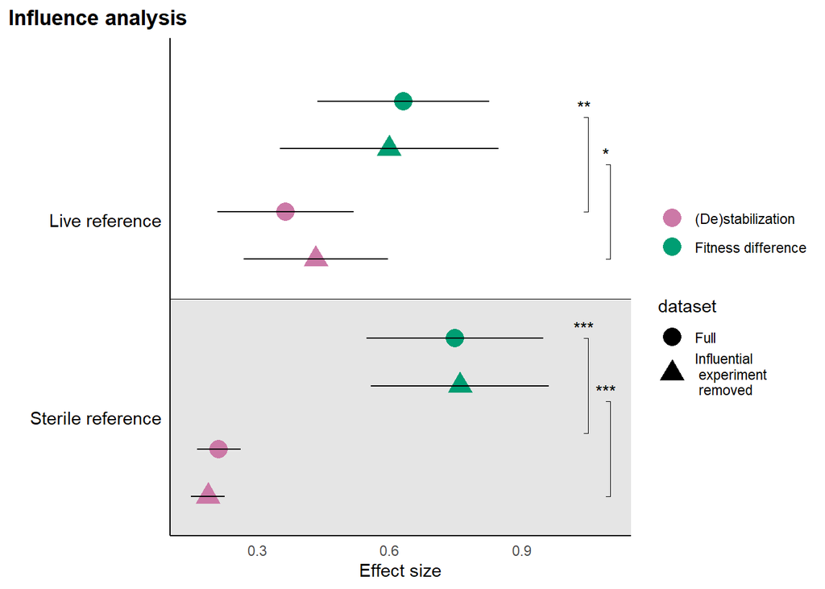

```r
# make dataframe to plot results after deletion
# for live reference dataset
q1.lr.deletion.plot <- bind_rows(conf_int(q1.lr.0.5, vcov = "CR2"),
                              #conf_int(q1.lr.0.5.no143, vcov = "CR2"),
                              conf_int(q1.lr.0.5.no143.138, vcov = "CR2")) %>%
  data.frame() %>%
  rownames_to_column("which")

q1.lr.deletion.plot <-
  q1.lr.deletion.plot %>%
  mutate(set = c("FD", "SD", "FD", "SD"),
         set = ifelse(set == "FD", "Fitness difference", "(De)stabilization"))

# for sterile reference dataset
q1.xs.deletion.plot <- bind_rows(conf_int(q1.xs.0.5, vcov = "CR2"),
                              conf_int(q1.xs.0.5.no33, vcov = "CR2")) %>%
  data.frame() %>%
  rownames_to_column("which")

q1.xs.deletion.plot <-
  q1.xs.deletion.plot %>%
  mutate(set = c("FD", "SD", "FD", "SD"),
         set = ifelse(set == "FD", "Fitness difference", "(De)stabilization"))

# combine results from both datasets
q1.deletion.plot <- bind_rows(q1.lr.deletion.plot, q1.xs.deletion.plot)
q1.deletion.plot <- q1.deletion.plot %>%
  mutate(dataset = rep(c("Full", "Full", "Influential\n experiment\n removed", "Influential\n experiment\n removed"), 2))%>%
  mutate(yval= rev(c(1, 1.7, 1.3, 2,
                     2.5, 3.2, 2.8, 3.5)))

# plotting
q1_deletion_plot <- ggplot(q1.deletion.plot, aes(y = beta, x = yval)) +
  geom_ribbon(aes(x = seq(0.75, 2.25, length.out = 8), ymin = -Inf, ymax = Inf), fill = "grey90") +
  geom_point(size = 5, aes(color = set, shape = dataset)) +
  geom_errorbar(aes(ymin = CI_L, ymax = CI_U), width = 0, size = .4) +
  geom_vline(xintercept = 2.25, size = 0.25) +
  scale_color_manual(name = "", values = c("#CC79A7", "#009E73")) +
  scale_x_continuous(breaks = c(1.5, 2.75),
                     expand = c(0,0), limits = c(0.75, 3.9),
                     labels = c("Sterile reference",
                                "Live reference")) +
  xlab("") +
  ylab("Effect size") +
  theme_plots() +
  theme(axis.text.y = element_text(size = 11, color = "black"),
        legend.position = "right",
        plot.title = element_text(face = "bold"),
        plot.title.position = "plot") +
    ggpubr::geom_bracket(xmin = c(1, 1.4, 2.5, 2.8),
                         xmax = c(1.6, 2, 3.1, 3.4),
                         y.position = c(1.1, 1.05, 1.1, 1.05),
                         label = c("***", "***", "*", "**"), tip.length = c(0.01, 0.01),
                         vjust = 0.1) +
  coord_flip() +
  labs(title = "Influence analysis")

q1_deletion_plot
```

```r
if(save_figures){
  ggsave("figures/q1_deletion_plot.png", q1_deletion_plot, bg = "transparent", height = 5, width = 8)
}
```

## Question 2

Question two asks, across species pairs, what is the net effect of microbes on competitive outcomes? In other words, how frequently does the balance of microbially mediated stabilization (or destabilization) and fitness differences predict species coexistence, exclusion, or priority effects.

### Meta-analysis approach (Fig. S7)

First, before looking into each individual species pairs, we start with a meta-analytical approach like Q1 to predict the overall competitive outcome given the *average* microbial effect. Here we do separate meta-analysis models for species pairs each each dataset with stabilizing or destabilizing effects of soil microbes. These results form the basis of Fig. S7 in the paper.

*Live soil reference*

First we run separate meta-analyses for species pairs with live reference soils and with positive vs. negative values of the stabilization metric. First we analyse pairs with microbial stabilization, and then analyze pairs with microbially mediated destabilization.

*Click `code` on the right for details*.

```r
# we first examine species pairs where interactions are STABILIZED by microbes
live_ref_long_q2 <-
  live_ref_long %>%
  # Get rid of the rows where SD < 0
  filter(set == "FD" | (set == "SD" & mean_value > 0)) %>%
  # Eliminate the species pairs whose SDs were eliminated in the previous step
  group_by(Experiment_SpPair) %>%
  mutate(n_rows = n()) %>%
  filter(n_rows > 1) %>%
  # Clean up the dataset
  select(-n_rows)

# run meta-analysis on stabilized pairs
q2.lr.0.5 <- run_metamod(which_df = live_ref_long_q2,
                         which_response_column = "absolute_FDSD_effects",
                         moderators = " ~ (set-1)",
                         impute_cov_r = 0.5)
```

**Live reference soil, species pairs with stabilizing effects of soil microbes**

```r
# check if SD and FD are different from zero
coef_test(q2.lr.0.5, vcov = "CR2") %>%
  kable() %>%
  kable_styling(full_width = 0)
```

|  | Coef | beta | SE | tstat | df_Satt | p_Satt |
| --- | --- | --- | --- | --- | --- | --- |
| setFD | setFD | 0.7203153 | 0.0966905 | 7.449697 | 10.35514 | 0.0000180 |
| setSD | setSD | 0.4385484 | 0.1093915 | 4.008982 | 11.20481 | 0.0019813 |

```r
# check if they are different from one another
Wald_test(q2.lr.0.5, constraints = constrain_equal(1:2),  vcov = "CR2") %>%
  kable() %>%
  kable_styling(full_width = 0)
```

| test | Fstat | delta | df_num | df_denom | p_val |
| --- | --- | --- | --- | --- | --- |
| HTZ | 22.05369 | 1 | 1 | 6.662667 | 0.0025311 |

For pairs where interactions are stabilized, their overall fitness difference exceeds the stabilizing effect.

Next, we turn to pairs with destabilizing effects of soil microbes (negative values of stabilization metric).

```r
# next, we look at pairs where interactions are DESTABILIZED by microbes
live_ref_long_q2_destab <-
  live_ref_long %>%
  # Get rid of the rows where SD > 0
  filter(set == "FD" | (set == "SD" & mean_value < 0)) %>%
  # Eliminate the species pairs whose SDs were eliminated in the previous step
  group_by(Experiment_SpPair) %>%
  mutate(n_rows = n()) %>%
  filter(n_rows > 1) %>%
  # Clean up the dataset
  select(-n_rows)

# meta-analytical model using only destabilized pairs
# note that the response variable is the strength (absolute value) of destabilization
q2.lr.0.5.destab <- run_metamod(which_df = live_ref_long_q2_destab,
                         which_response_column = "absolute_FDSD_effects",
                         moderators = " ~ (set-1)",
                         impute_cov_r = 0.5)
```

**Live reference soil, species pairs with destabilizing effects of soil microbes**

```r
# check if the strength of destabilization and FD are different from zero
coef_test(q2.lr.0.5.destab, vcov = "CR2") %>%
  kable() %>%
  kable_styling(full_width = 0)
```

|  | Coef | beta | SE | tstat | df_Satt | p_Satt |
| --- | --- | --- | --- | --- | --- | --- |
| setFD | setFD | 0.5294017 | 0.1815242 | 2.916425 | 6.010139 | 0.0267034 |
| setSD | setSD | 0.2808761 | 0.0578024 | 4.859245 | 5.144896 | 0.0042949 |

```r
# check if the strength of destabilization and FD are different from one another
Wald_test(q2.lr.0.5.destab, constraints = constrain_equal(1:2),  vcov = "CR2") %>%
  kable() %>%
  kable_styling(full_width = 0)
```

| test | Fstat | delta | df_num | df_denom | p_val |
| --- | --- | --- | --- | --- | --- |
| HTZ | 2.708292 | 1 | 1 | 5.720508 | 0.1533417 |

For pairs where interactions are destabilized, their magnitude of destabilizing effect are not significantly different from FD.

*Sterile soil reference*

```r
# start with stabilized pairs:
sterile_ref_long_q2 <-
  sterile_ref_long %>%
  # Get rid of the rows where SD < 0
  filter(set == "FD" | (set == "SD" & mean_value > 0)) %>%
  # Eliminate the species pairs whose SDs were eliminated in the previous step
  group_by(Experiment_SpPair) %>%
  mutate(n_rows = n()) %>%
  filter(n_rows > 1) %>%
  # Clean up the dataset
  select(-n_rows)

# run meta-analysis on stabilized pairs
q2.xs.0.5 <- run_metamod(which_df = sterile_ref_long_q2,
                         which_response_column = "absolute_FDSD_effects",
                         moderators = " ~ (set-1)",
                         impute_cov_r = 0.5)
```

**Sterile reference soils, species pairs with stabilizing effects of soil microbes**

```r
# check stabilization and FD are different from zero
coef_test(q2.xs.0.5, vcov = "CR2") %>%
  kable() %>%
  kable_styling(full_width = F)
```

|  | Coef | beta | SE | tstat | df_Satt | p_Satt |
| --- | --- | --- | --- | --- | --- | --- |
| setFD | setFD | 0.7866934 | 0.1176843 | 6.684779 | 40.04461 | 1e-07 |
| setSD | setSD | 0.1992078 | 0.0282220 | 7.058601 | 45.02828 | 0e+00 |

```r
# check if they are different from one another
Wald_test(q2.xs.0.5, constraints = constrain_equal(1:2),  vcov = "CR2") %>%
  kable() %>%
  kable_styling(full_width = F)
```

| test | Fstat | delta | df_num | df_denom | p_val |
| --- | --- | --- | --- | --- | --- |
| HTZ | 25.85554 | 1 | 1 | 39.92172 | 9.1e-06 |

For pairs where interactions are stabilized, their overall FD exceeds the magnitude of stabilizing effect

```r
# then focus on destabilized pairs:
sterile_ref_long_q2_destab <-
  sterile_ref_long %>%
  # Get rid of the rows where SD > 0
  filter(set == "FD" | (set == "SD" & mean_value < 0)) %>%
  # Eliminate the species pairs whose SDs were eliminated in the previous step
  group_by(Experiment_SpPair) %>%
  mutate(n_rows = n()) %>%
  filter(n_rows > 1) %>%
  # Clean up the dataset
  select(-n_rows)

# run meta-analysis on destabilized pairs:
q2.xs.0.5.destab <- run_metamod(which_df = sterile_ref_long_q2_destab,
                         which_response_column = "absolute_FDSD_effects",
                         moderators = " ~ (set-1)",
                         impute_cov_r = 0.5)
```

**Sterile reference soil, species pairs with destabilizing effects of soil microbes**

```r
# check if FD and strength of destabilization are different from zero
coef_test(q2.xs.0.5.destab, vcov = "CR2") %>%
  kable() %>%
  kable_styling(full_width = F)
```

|  | Coef | beta | SE | tstat | df_Satt | p_Satt |
| --- | --- | --- | --- | --- | --- | --- |
| setFD | setFD | 0.8935215 | 0.1319192 | 6.773250 | 34.87086 | 1e-07 |
| setSD | setSD | 0.2251811 | 0.0340159 | 6.619881 | 29.69731 | 3e-07 |

```r
# check if they are different from one another
Wald_test(q2.xs.0.5.destab, constraints = constrain_equal(1:2),  vcov = "CR2") %>%
  kable() %>%
  kable_styling(full_width = F)
```

| test | Fstat | delta | df_num | df_denom | p_val |
| --- | --- | --- | --- | --- | --- |
| HTZ | 36.31299 | 1 | 1 | 34.04958 | 8e-07 |

For pairs where interactions are destabilized, their overall FD exceeds the magnitude of destabilizing effect.

*Visualize results for Fig. S7*  
*Click on `code` to the right for details on our visualizations*.

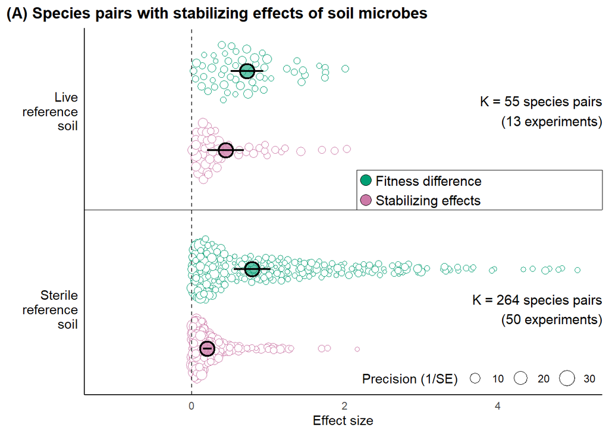

```r
# combine results (estimates) from both reference datasets:
q2b_plots_df_stabilizing <- bind_rows(
  data.frame(conf_int(q2.xs.0.5, vcov = "CR2")),
  data.frame(conf_int(q2.lr.0.5, vcov = "CR2"))
)

q2b_plots_df_stabilizing <-
  q2b_plots_df_stabilizing %>%
  mutate(yval = c(1.2, 0.8, 2.2, 1.8),
         which_source = rep(c("XS", "LR"), each = 2),
         effect_type = rep(c("Fitness difference",
                 "(De)stabilization"), 2))

# calculating prediction intervals of estimated SD and FD
q2.stab.prediction_intervals <- bind_rows(data.frame(predict.rma(q2.xs.0.5)[1:2,]),
                                  data.frame(predict.rma(q2.lr.0.5)[1:2,])) %>%
  mutate(which_source = rep(c("XS", "LR"), each = 2),
         effect_type = c("(De)stabilization", "Fitness difference", "(De)stabilization", "Fitness difference"))

q2b_plots_df_stabilizing <- left_join(x = q2b_plots_df_stabilizing, y = q2.stab.prediction_intervals, by = c("effect_type", "which_source"))

# plotting
(q2_plot_stabilizing <-
    ggplot(q2b_plots_df_stabilizing) +
    ggbeeswarm::geom_quasirandom(data = sterile_ref_long_q2,
                                 aes(x = absolute_FDSD_effects, y = yval, size = scale, color = effect_type),
                                 groupOnX = F, alpha = 1, pch = 21, fill = "transparent", stroke = 0.25) +
    ggbeeswarm::geom_quasirandom(data = live_ref_long_q2,
                                 aes(x = absolute_FDSD_effects, y = yval, size = scale, color = effect_type),
                                 groupOnX = F, alpha = 1, pch = 21, fill = "transparent", stroke = 0.5) +
    geom_point(aes(x = beta, y = yval, fill = effect_type),
               size = 5, stroke = 1.25, shape = 21) +
    geom_errorbarh(aes(y = yval, xmin = CI_L, xmax = CI_U), height = 0, size = 0.8) +
    geom_hline(yintercept = 1.5, size = .25) +
    geom_vline(xintercept = 0, linetype = 2, size = .5, color = "grey25") +
    annotate("text", x = Inf, y = 1, label = paste0("K = ", nrow(sterile_ref_long_q2)/2,
                                                    " species pairs\n (",
                                                    length(unique(sterile_ref_long_q2$Experiment)),
                                                    " experiments)"), hjust = 1, size = 4) +
    annotate("text", x = Inf, y = 2, label = paste0("K = ", nrow(live_ref_long_q2)/2,
                                                    " species pairs\n (",
                                                    length(unique(live_ref_long_q2$Experiment)),
                                                    " experiments)"), hjust = 1, size = 4) +
  scale_fill_manual(name = "", values = rev(c(alpha("#009E73", 0.6), alpha("#CC79A7", 0.75)))) +
  scale_color_manual(name = "", values = rev(c("#009E73", "#CC79A7", "#009E73","#CC79A7"))) +
  scale_y_continuous(name = "", breaks = c(1,2), labels = c("Sterile\nreference\nsoil","Live\nreference\nsoil")) +
  scale_x_continuous(limits = c(-1.1, 5.05), breaks = c(0, 2,4)) +
  scale_size_continuous(name = "Precision (1/SE)", breaks = c(10, 20, 30)) +
  xlab("Effect size") +
  theme_plots() +

  annotate("segment", x = 2.15, xend = Inf, y = c(1.5, 1.7), yend = c(1.5,1.7), size = .25) +
  annotate("segment", x = c(2.15, Inf), xend = c(2.15, Inf), y = 1.5, yend = 1.7, size = .25)  +
  geom_point(aes(x = 2.27, y = 1.65), size = 4, shape = 21, fill = c("#009E73")) +
  geom_point(aes(x = 2.27, y = 1.55), size = 4, shape = 21, fill = c("#CC79A7")) +
  annotate("text", x = 2.4, y = 1.65, label = "Fitness difference", hjust = 0, size = 4) +
  annotate("text", x = 2.4, y = 1.55, label = "Stabilizing effects", hjust = 0, size = 4) +

  guides(fill = "none", color = "none") +
  labs(title = "(A) Species pairs with stabilizing effects of soil microbes") +
  theme(axis.text.y = element_text(color = "black", size = 11),
        legend.position= c(1, 0),
        legend.direction = "horizontal",
        legend.justification = c(1, 0),
        plot.title.position = "plot",
        plot.title = element_text(face = "bold"))
)
```

**For pairs with destabilizing effects (both reference types)**

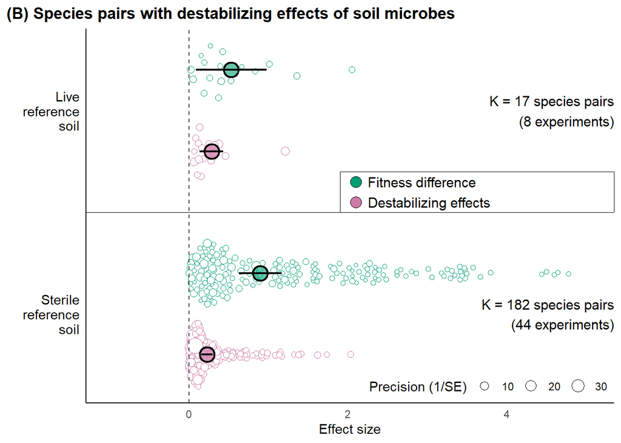

```r
# combine results (estimates) from both reference datasets:
q2b_plots_df_destabilizing <- bind_rows(
  data.frame(conf_int(q2.xs.0.5.destab, vcov = "CR2")),
  data.frame(conf_int(q2.lr.0.5.destab, vcov = "CR2"))
)

q2b_plots_df_destabilizing <-
  q2b_plots_df_destabilizing %>%
  mutate(yval = c(1.2, 0.8, 2.2, 1.8),
         which_source = rep(c("XS", "LR"), each = 2),
         effect_type = rep(c("Fitness difference",
                 "(De)stabilization"), 2))

# calculating prediction intervals for destailization and FD estimates
q2.destab.prediction_intervals <- bind_rows(data.frame(predict.rma(q2.xs.0.5.destab)[1:2,]),
                                          data.frame(predict.rma(q2.lr.0.5.destab)[1:2,])) %>%
  mutate(which_source = rep(c("XS", "LR"), each = 2),
         effect_type = c("(De)stabilization", "Fitness difference", "(De)stabilization", "Fitness difference"))

q2b_plots_df_destabilizing <- left_join(x = q2b_plots_df_destabilizing,
                                        y = q2.destab.prediction_intervals,
                                        by = c("effect_type", "which_source"))

# plotting
(q2_plot_destabilizing <- ggplot(q2b_plots_df_destabilizing) +
  ggbeeswarm::geom_quasirandom(data = sterile_ref_long_q2_destab,
                               aes(x = absolute_FDSD_effects, y = yval, size = scale, color = effect_type),
                               groupOnX = F, alpha = 1, pch = 21, fill = "transparent", stroke = 0.25) +
  ggbeeswarm::geom_quasirandom(data = live_ref_long_q2_destab,
                               aes(x = absolute_FDSD_effects, y = yval, size = scale, color = effect_type),
                               groupOnX = F, alpha = 1, pch = 21, fill = "transparent", stroke = 0.5) +
  geom_point(aes(x = beta, y = yval, fill = effect_type),
             size = 5, stroke = 1.25, shape = 21) +
  geom_errorbarh(aes(y = yval, xmin = CI_L, xmax = CI_U), height = 0, size = 0.8) +
  geom_hline(yintercept = 1.5, size = .25) +
  geom_vline(xintercept = 0, linetype = 2, size = .5, color = "grey25") +
    annotate("text", x = Inf, y = 1, label = paste0("K = ", nrow(sterile_ref_long_q2_destab)/2,
                                                    " species pairs\n (",
                                                    length(unique(sterile_ref_long_q2_destab$Experiment)),
                                                    " experiments)"), hjust = 1, size = 4) +
    annotate("text", x = Inf, y = 2, label = paste0("K = ", nrow(live_ref_long_q2_destab)/2,
                                                    " species pairs\n (",
                                                    length(unique(live_ref_long_q2_destab$Experiment)),
                                                    " experiments)"), hjust = 1, size = 4) +

  scale_fill_manual(name = "", values = rev(c(alpha("#009E73", 0.6), alpha("#CC79A7", 0.75)))) +
  scale_color_manual(name = "", values = rev(c("#009E73", "#CC79A7", "#009E73","#CC79A7"))) +
  scale_y_continuous(name = "", breaks = c(1,2), labels = c("Sterile\nreference\nsoil", "Live\nreference\nsoil")) +
  scale_x_continuous(limits = c(-1, 5.05), breaks = c(0, 2,4)) +
  scale_size_continuous(name = "Precision (1/SE)", breaks = c(10, 20, 30)) +
  xlab("Effect size") +
  theme_plots() +

    annotate("segment", x = 1.9, xend = Inf, y = c(1.5, 1.7), yend = c(1.5,1.7), size = .25) +
    annotate("segment", x = c(1.9, Inf), xend = c(1.9, Inf), y = 1.5, yend = 1.7, size = .25)  +
    geom_point(aes(x = 2.1, y = 1.65), size = 4, shape = 21, fill = c("#009E73")) +
    geom_point(aes(x = 2.1, y = 1.55), size = 4, shape = 21, fill = c("#CC79A7")) +
    annotate("text", x = 2.25, y = 1.65, label = "Fitness difference", hjust = 0, size = 4) +
    annotate("text", x = 2.25, y = 1.55, label = "Destabilizing effects", hjust = 0, size = 4) +

  guides(fill = "none", color = "none") +
  labs(title = "(B) Species pairs with destabilizing effects of soil microbes") +
  theme(axis.text.y = element_text(color = "black", size = 11),
        legend.position= c(1, 0),
        legend.direction = "horizontal",
        legend.justification = c(1, 0),
        plot.title.position = "plot",
        plot.title = element_text(face = "bold"))
)
```

*For the supplemental figures we put these two panels together into one figure, see code below for details.*

```r
# combine figures of stabilizing and destabilizing pairs
q2b_plot <- q2_plot_stabilizing + q2_plot_destabilizing
if(save_figures) {
  ggsave("figures/q2_meta-plot.png", width = 11, height = 5)
}
```

### Pairwise direct comparison of stabilization and fitness differences

To evaluate the pairwise competitive outcome, we need to directly compare strength of stabilization or destabilization and fitness differences between individual species pair. We first just compare the *mean* values of the stabilization and fitness differences (note that here stabilization is the signed metric, no longer the absolute value as in Q1) between species, and later we incorporate the uncertainty of these estimates into our analysis.

#### Live reference dataset

```r
# how many pairs are coexistence by MEAN FD and SD
# sum(live_ref$mean_SD>0 & live_ref$mean_IGR >0)
# what's the frequency of coexistence among all three possible outcomes?
paste0("coexistence: ", percent(sum(live_ref$mean_SD>0 & live_ref$mean_IGR >0)/nrow(live_ref)))
```

```
## [1] "coexistence: 22%"
```

```r
# sum(live_ref$mean_SD<0 & abs(live_ref$mean_SD)>live_ref$abs_FD)
# how frequently are priority effects?
paste0("priority effects: ", percent(sum(live_ref$mean_SD<0 & abs(live_ref$mean_SD)>live_ref$abs_FD)/nrow(live_ref)))
```

```
## [1] "priority effects: 6%"
```

```r
# sum(abs(live_ref$mean_SD)<live_ref$abs_FD)
# how frequently are competitive exclusions?
paste0("exclusions: ", percent(sum(abs(live_ref$mean_SD)<live_ref$abs_FD)/nrow(live_ref)))
```

```
## [1] "exclusions: 72%"
```

#### Sterile reference dataset

```r
# sum(sterile_ref$mean_SD>0 & sterile_ref$mean_IGR >0)
# how frequently are coexistence?
paste0("coexistence: ", percent(sum(sterile_ref$mean_SD>0 & sterile_ref$mean_IGR >0)/nrow(sterile_ref)))
```

```
## [1] "coexistence: 12%"
```

```r
# sum(sterile_ref$mean_SD<0 & abs(sterile_ref$mean_SD)>sterile_ref$abs_FD)
# how frequently are priority effects?
paste0("priority effects: ", percent(sum(sterile_ref$mean_SD<0 & abs(sterile_ref$mean_SD)>sterile_ref$abs_FD)/nrow(sterile_ref)))
```

```
## [1] "priority effects: 4%"
```

```r
# sum(abs(sterile_ref$mean_SD)<sterile_ref$abs_FD)
# how frequently are competitive exclusions?
paste0("competitive exclusion: ", percent(sum(abs(sterile_ref$mean_SD)<sterile_ref$abs_FD)/nrow(sterile_ref)))
```

```
## [1] "competitive exclusion: 83%"
```

### Incorporating the uncertainty into predictions of coexistence outcomes

We further incorporate empirical uncertainties into the inference via a sampling approach. To do this sampling, we use the custom function `simulation_ci`, which we defined in an earlier section.

#### Live reference dataset

We start with conducting the analysis on species pairs with growth in live soil providing the reference. We then plot the outcomes as piecharts onto the base coexistence plot defined in the first section of this document.  
*Click `code` to the right for details on how we use the new function `simulation_ci()` to conduct this analysis.*

```r
# simulate competitive outcomes based on distributions
# with the mean and sd of each pairwise comparisons
FL_simulation_out <- simulation_ci(data_with_SDFD = live_ref)
live_ref_sims <- FL_simulation_out$outcomes_by_pair
live_ref_sims_by_run <- FL_simulation_out$outcomes_by_run

# Define a new function to summarize simulation outcomes
percent_outcomes <- function(outcomes_by_run) {
  format_range <- function(range) {
    paste0(range[2], " (", range[1], "-", range[3],")")
  }
  # the 5%, 50%, and 95% quantiles for numbers of coexistence outcomes
  range.exclusion <-  percent(quantile(outcomes_by_run$n_reps_exclusion/rowSums(outcomes_by_run),
                                       c(0.05, 0.5, 0.95)), accuracy = .1) %>% format_range
  range.coex <- percent(quantile(outcomes_by_run$n_reps_coex/rowSums(outcomes_by_run),
                                 c(0.05, 0.5, 0.95)), accuracy = .1) %>% format_range
  range.pes <- percent(quantile(outcomes_by_run$n_reps_pes/rowSums(outcomes_by_run),
                                c(0.05, 0.5, 0.95)), accuracy = .1) %>% format_range
  return(list(exclusion = range.exclusion, coex = range.coex, pes = range.pes))
}

percent_outcomes(live_ref_sims_by_run)
```

```
## $exclusion
## [1] "69.4% (62.5%-76.4%)"
##
## $coex
## [1] "22.2% (16.7%-29.2%)"
##
## $pes
## [1] "6.9% (4.2%-11.1%)"
```

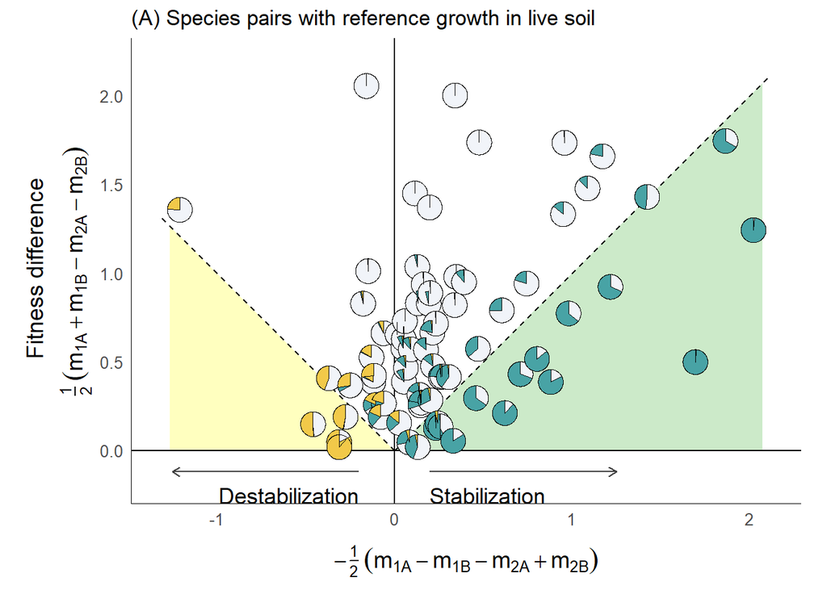

```r
# define the data range of the plot
x_min <- with(live_ref_sims, min(mean_SD))-0.1
x_max <- with(live_ref_sims, max(mean_SD))+0.1
y_min <- with(live_ref_sims, min(abs(mean_FD)))-0.15
y_max <- with(live_ref_sims, max(abs(mean_FD)))+0.15

# adapt a previously defined base plot
base_coex_plot1 <- base_coex_plot
base_coex_plot1$layers[7:8] <- NULL
base_coex_plot1 <- base_coex_plot1 +
  annotate("text", x = 0.2, y = -Inf, hjust = 0, vjust = 0, label = "Stabilization", color = "black", size = 4.8) +
  annotate("text", x = -0.2, y = -Inf, hjust = 1, vjust = 0, label = "Destabilization",  color = "black", size = 4.8) +
  theme(axis.title.x = element_text(margin = margin(t = 0)))
# base_coex_plot1

# plotting
(scatterpie_FL <- base_coex_plot1 +
  scale_x_continuous(limits = c(x_min, x_max)) +
  scale_y_continuous(limits = c(y_min-0.05, y_max)) +
  annotate("segment", x = 0, y = 0, xend =  min(x_max, y_max),
           yend = min(x_max, y_max),
           linetype = 2) +
  annotate("segment", x = 0, y = 0, xend =  max(x_min, -y_max),
           yend =  min(-x_min, y_max),
           linetype = 2) +
  geom_scatterpie(aes(x=mean_SD, y=abs(mean_FD), r = 0.07),
                  data=live_ref_sims, size = 0.15,
                  cols=c("n_reps_exclusion", "n_reps_coex", "n_reps_pes")) +
  scale_fill_manual(values = c( "#f1f4f9", "#48a3a5", "#f2c949"),
                    labels =  c( "exclusion", "coexistence", "priority effect"),
                    name = "") +
    guides(fill = "none") +
    labs(title = "(A) Species pairs with reference growth in live soil") +
  coord_fixed() +
  theme(axis.line = element_line(size = 0),
        legend.position = "none",
        legend.background = element_rect(colour = "grey50", size = .3),
        legend.text = element_text(size = 13),
        legend.title = element_text(size = 8, face = "bold"),
        axis.title = element_text(size = 14),
        axis.text = element_text(size = 10))
)
```

#### Sterile reference dataset

Repeat the procedure for species pairs with growth in sterile soil providing the reference.

```r
# simulate competitive outcomes based on distributions
# with the mean and sd of each pairwise comparisons
# details see the function `simulation_ci` defined at the beginning
sterile_simulation_out <- simulation_ci(data_with_SDFD = sterile_ref)
sterile_ref_sims <- sterile_simulation_out$outcomes_by_pair
sterile_ref_sims_by_run <- sterile_simulation_out$outcomes_by_run

# call the function defined above to summarize simulation outcomes
percent_outcomes(sterile_ref_sims_by_run)
```

```
## $exclusion
## [1] "81.2% (78.7%-83.6%)"
##
## $coex
## [1] "12.8% (10.8%-14.8%)"
##
## $pes
## [1] "6.1% (4.5%-7.6%)"
```

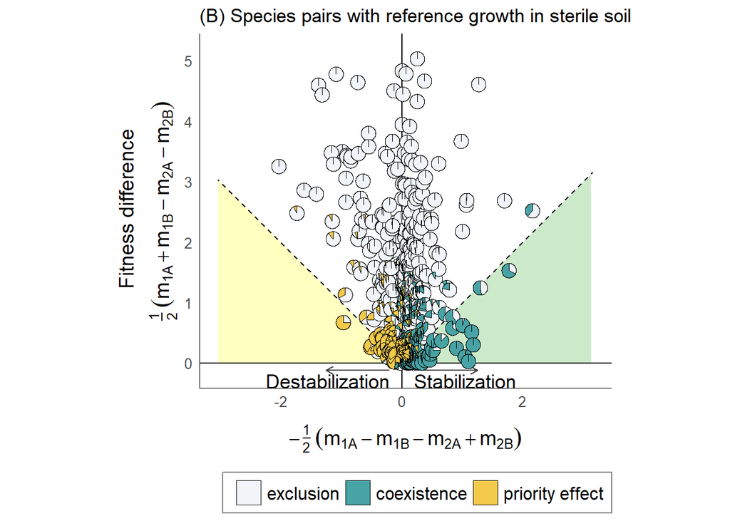

```r
# define data range for plotting
x_min <- with(sterile_ref_sims, min(mean_SD))-1
x_max <- with(sterile_ref_sims, max(mean_SD))+1
y_min <- with(sterile_ref_sims, min(abs(mean_FD)))-0.15
y_max <- with(sterile_ref_sims, max(abs(mean_FD)))+0.15

# plotting
(scatterpie_XS_all <-
    base_coex_plot1 +
    scale_x_continuous(limits = c(x_min, x_max)) +
    scale_y_continuous(limits = c(y_min, y_max)) +
    annotate("segment", x = 0, y = 0, xend =  min(x_max, y_max),
             yend = min(x_max, y_max),
             linetype = 2) +
    annotate("segment", x = 0, y = 0, xend = max(x_min, -y_max),
             yend = min(-x_min, y_max),
             linetype = 2) +

    geom_scatterpie(aes(x=mean_SD, y=abs(mean_FD), r = 0.12),
                    data= sterile_ref_sims, size = 0.15,
                    cols=c("n_reps_exclusion", "n_reps_coex", "n_reps_pes")) +
    scale_fill_manual(labels =  c( "exclusion", "coexistence","priority effect"),
                      values = c( "#f1f4f9", "#48a3a5", "#f2c949"),
                      name = "") +
    coord_fixed() +
    labs(title = "(B) Species pairs with reference growth in sterile soil") +
    theme(axis.line = element_line(size = 0),
          legend.justification =c(1,0),
          legend.position = "bottom",
          # legend.position = c(0.3,0.1),
          legend.text = element_text(size = 12.5),
          legend.background = element_rect(colour = "grey50"),
          legend.title = element_text(size = 8, face = "bold"),
          axis.title = element_text(size = 14),
          axis.text = element_text(size = 10))
)
```

*For the main text, we assembled these panels together into one figure (Figure 4), see code below for details.*

```r
# Combine the two plots together for Figure 4 of the paper
scatterpies_combined <-
  scatterpie_FL + scatterpie_XS_all +
  plot_layout(guides = "collect", widths = c(1,1)) &
  theme(legend.position = "bottom")
if(save_figures) {
  ggsave("figures/scatterpies_combined.png",
         plot = scatterpies_combined, height = 5.5, width = 11)
  ggsave("figures/scatterpies_combined.eps",
         plot = scatterpies_combined, height = 5.5, width = 11,
         bg = "transparent")
}
```

*Now we can do a sort of “Moderator analysis” for this sampling approach.*.  
This becomes Table S1-2 in the manuscript.

```r
### "Moderator analysis"

### live reference dataset ----------------------
# percentage outcomes in pairs using Low fraction of inoculum
FL_simulation_out_FILow <- simulation_ci(data_with_SDFD = live_ref %>% filter(`Fraction inoculum` <= 0.25))
# percent_outcomes(FL_simulation_out_FILow$outcomes_by_run)

# percentage outcomes in pairs using High fraction of inoculum
FL_simulation_out_FIHigh <- simulation_ci(data_with_SDFD = live_ref %>% filter(`Fraction inoculum` > 0.25))
# percent_outcomes(FL_simulation_out_FIHigh$outcomes_by_run)


# percent outcomes: training environment in Lab/Greenhouse
FL_simulation_out_TrainGreenhouse <- simulation_ci(data_with_SDFD = live_ref %>% filter(`Training environment` == "Lab"))
# percent_outcomes(FL_simulation_out_TrainGreenhouse$outcomes_by_run)

# percent outcomes: training environment in Field
FL_simulation_out_TrainField <- simulation_ci(data_with_SDFD = live_ref %>% filter(`Training environment` == "Field"))
# percent_outcomes(FL_simulation_out_TrainField$outcomes_by_run)


# percent outcomes: response plants grew individually
FL_simulation_out_ResponseInd <- simulation_ci(data_with_SDFD = live_ref %>% filter(`Testing community` == "Individual"))
# percent_outcomes(FL_simulation_out_ResponseInd$outcomes_by_run)

# percent outcomes: response plants grew in communities
FL_simulation_out_ResponseComm <- simulation_ci(data_with_SDFD = live_ref %>% filter(`Testing community` == "Community"))
# percent_outcomes(FL_simulation_out_ResponseComm$outcomes_by_run)

# percent outcomes: response plants grew in populations
FL_simulation_out_ResponsePop <- simulation_ci(data_with_SDFD = live_ref %>% filter(`Testing community` == "Population"))
# percent_outcomes(FL_simulation_out_ResponsePop$outcomes_by_run)


### sterile reference dataset --------------------------
# percent outcomes: Low fraction inoculum
XS_simulation_out_FILow <- simulation_ci(data_with_SDFD = sterile_ref %>% filter(`Fraction inoculum` < 0.25))
# percent_outcomes(XS_simulation_out_FILow$outcomes_by_run)

# percent outcomes: High fraction inoculum
XS_simulation_out_FIHigh <- simulation_ci(data_with_SDFD = sterile_ref %>% filter(`Fraction inoculum` > 0.25))
# percent_outcomes(XS_simulation_out_FIHigh$outcomes_by_run)


# percent outcomes: training environment in Lab/Greenhouse
XS_simulation_out_TrainGreenhouse <- simulation_ci(data_with_SDFD = sterile_ref %>% filter(`Training environment` == "Lab"))
# percent_outcomes(XS_simulation_out_TrainGreenhouse$outcomes_by_run)

# percent outcomes: training environment in Field
XS_simulation_out_TrainField <- simulation_ci(data_with_SDFD = sterile_ref %>% filter(`Training environment` == "Field"))
# percent_outcomes(XS_simulation_out_TrainField$outcomes_by_run)


# percent outcomes: response plants grew individually
XS_simulation_out_ResponseInd <- simulation_ci(data_with_SDFD = sterile_ref %>% filter(`Testing community` == "Individual"))
# percent_outcomes(XS_simulation_out_ResponseInd$outcomes_by_run)

# percent outcomes: response plants grew in communities
XS_simulation_out_ResponseComm <- simulation_ci(data_with_SDFD = sterile_ref %>% filter(`Testing community` == "Community"))
# percent_outcomes(XS_simulation_out_ResponseComm$outcomes_by_run)

# percent outcomes: response plants grew in populations
XS_simulation_out_ResponsePop <- simulation_ci(data_with_SDFD = sterile_ref %>% filter(`Testing community` == "Population"))
# percent_outcomes(XS_simulation_out_ResponsePop$outcomes_by_run)


# percent outcomes: autoclaving as the sterilization method
XS_simulation_out_SterileAutoclave <- simulation_ci(data_with_SDFD = sterile_ref %>% filter(Study_sterilization_method == "autoclaving"))
# percent_outcomes(XS_simulation_out_SterileAutoclave$outcomes_by_run)

# percent outcomes: gamma irradiation as the sterilization method
XS_simulation_out_SterileGamma <- simulation_ci(data_with_SDFD = sterile_ref %>% filter(Study_sterilization_method == "gamma irradiation"))
# percent_outcomes(XS_simulation_out_SterileGamma$outcomes_by_run)

# percent outcomes: heating as the sterilization method
XS_simulation_out_SterileHeat <- simulation_ci(data_with_SDFD = sterile_ref %>% filter(Study_sterilization_method == "heating"))
# percent_outcomes(XS_simulation_out_SterileHeat$outcomes_by_run)

# percent outcomes: other sterilization method
XS_simulation_out_SterileOther <- simulation_ci(data_with_SDFD = sterile_ref %>% filter(!(Study_sterilization_method %in%                                                   c("autoclaving", "gamma irradiation", "heating"))))
# percent_outcomes(XS_simulation_out_SterileOther$outcomes_by_run)


# percent outcomes: sterilized soil came from the greenhouse
XS_simulation_out_SterileSoilGreenhouse <- simulation_ci(data_with_SDFD = sterile_ref %>% filter(control_type == "GS"))
# percent_outcomes(XS_simulation_out_SterileSoilGreenhouse$outcomes_by_run)

# percent outcomes: sterilized soil came from the field
XS_simulation_out_SterileSoilField <- simulation_ci(data_with_SDFD = sterile_ref %>% filter(control_type == "FS"))
# percent_outcomes(XS_simulation_out_SterileSoilField$outcomes_by_run)

# percent outcomes: sterilized soil came from cultivated soil
XS_simulation_out_SterileSoilCS <- simulation_ci(data_with_SDFD = sterile_ref %>% filter(control_type == "CS"))
# percent_outcomes(XS_simulation_out_SterileSoilCS$outcomes_by_run)

# percent outcomes: sterilized soil came from cultivated and mixed soil
XS_simulation_out_SterileSoilCmS <- simulation_ci(data_with_SDFD = sterile_ref %>% filter(control_type == "CmS"))
# percent_outcomes(XS_simulation_out_SterileSoilCmS$outcomes_by_run)
```

**Table S.1: table of outcomes for live soil reference**

```r
options(kableExtra.latex.load_packages = FALSE)
# combining 'moderator analysis' results for the sampling of live reference data
table_of_things <-
  rbind(c("Overall",(t(unlist(percent_outcomes(live_ref_sims_by_run))))),

      c("Low",t(unlist(percent_outcomes(FL_simulation_out_FILow$outcomes_by_run)))),
      c("High",t(unlist(percent_outcomes(FL_simulation_out_FIHigh$outcomes_by_run)))),

      c("Field",t(unlist(percent_outcomes(FL_simulation_out_TrainField$outcomes_by_run)))),
      c("Greenhouse",t(unlist(percent_outcomes(FL_simulation_out_TrainGreenhouse$outcomes_by_run)))),

      c("Individual",t(unlist(percent_outcomes(FL_simulation_out_ResponseInd$outcomes_by_run)))),
      c("Population",t(unlist(percent_outcomes(FL_simulation_out_ResponsePop$outcomes_by_run)))),
      c("Community",t(unlist(percent_outcomes(FL_simulation_out_ResponseComm$outcomes_by_run))))

      ) %>%
  as_tibble() %>%
  mutate(category = c("Overall",
                      "Inoculation fraction", "Inoculation fraction",
                      "Training phase location", "Training phase location",
                      "Response phase growth type", "Response phase growth type", "Response phase growth type")) %>%
  rename("Method" = V1,
         "Exclusion" = V2,
         "Coexistence" = V3,
         "Priority effects" = V4) %>%
  select(category, Method, Coexistence, `Priority effects`, Exclusion) %>%
  kable(format = "latex", booktabs = T,align = "llccc") %>%
  # kable_styling(latex_options = "striped",
  #                           stripe_index = c(2,3, 6,7,8)) %>%
  column_spec(c(1,3,4,5), width = "1.1in")  %>%
  row_spec(c(2:3,6:8) - 1, extra_latex_after = "\\rowcolor{gray!10}") %>%
  collapse_rows(1, latex_hline = "none")

if(save_figures) {
  saveRDS(object = table_of_things, file = "figures/table_S1.Rds")
}

# Code to print table in HTML:
rbind(c("Overall",(t(unlist(percent_outcomes(live_ref_sims_by_run))))),

      c("Low",t(unlist(percent_outcomes(FL_simulation_out_FILow$outcomes_by_run)))),
      c("High",t(unlist(percent_outcomes(FL_simulation_out_FIHigh$outcomes_by_run)))),

      c("Field",t(unlist(percent_outcomes(FL_simulation_out_TrainField$outcomes_by_run)))),
      c("Greenhouse",t(unlist(percent_outcomes(FL_simulation_out_TrainGreenhouse$outcomes_by_run)))),

      c("Individual",t(unlist(percent_outcomes(FL_simulation_out_ResponseInd$outcomes_by_run)))),
      c("Population",t(unlist(percent_outcomes(FL_simulation_out_ResponsePop$outcomes_by_run)))),
      c("Community",t(unlist(percent_outcomes(FL_simulation_out_ResponseComm$outcomes_by_run))))

      ) %>%
  as_tibble() %>%
  mutate(category = c("Overall",
                      "Inoculation fraction", "Inoculation fraction",
                      "Training phase location", "Training phase location",
                      "Response phase growth type", "Response phase growth type", "Response phase growth type")) %>%
  rename("Method" = V1,
         "Exclusion" = V2,
         "Coexistence" = V3,
         "Priority effects" = V4) %>%
  select(category, Method, Coexistence, `Priority effects`, Exclusion) %>%
  kable(align = "llccc")
```

| category | Method | Coexistence | Priority effects | Exclusion |
| --- | --- | --- | --- | --- |
| Overall | Overall | 22.2% (16.7%-29.2%) | 6.9% (4.2%-11.1%) | 69.4% (62.5%-76.4%) |
| Inoculation fraction | Low | 17.6% (5.9%-29.4%) | 5.9% (0.0%-17.6%) | 76.5% (58.8%-88.2%) |
| Inoculation fraction | High | 23.6% (18.2%-30.9%) | 7.3% (3.6%-12.7%) | 67.3% (60.0%-76.4%) |
| Training phase location | Field | 28.6% (14.3%-42.9%) | 21.4% (7.1%-28.6%) | 50.0% (35.7%-71.4%) |
| Training phase location | Greenhouse | 22.4% (15.5%-27.6%) | 3.4% (1.7%-8.6%) | 74.1% (67.2%-81.0%) |
| Response phase growth type | Individual | 23.6% (16.4%-30.9%) | 7.3% (3.6%-12.7%) | 69.1% (60.0%-76.4%) |
| Response phase growth type | Population | 0.0% (0.0%-50.0%) | 0.0% (0.0%-50.0%) | 50.0% (0.0%-100.0%) |
| Response phase growth type | Community | 20.0% (6.7%-33.3%) | 6.7% (0.0%-13.3%) | 73.3% (60.0%-86.7%) |

**Table S.2: table of outcomes for sterile soil reference**

```r
# combining 'moderator analysis' results for the sampling of sterile reference data
table_of_things_sterile <-
  rbind(c("Overall",(t(unlist(percent_outcomes(sterile_ref_sims_by_run))))),

        c("Low",t(unlist(percent_outcomes(XS_simulation_out_FILow$outcomes_by_run)))),
        c("High",t(unlist(percent_outcomes(XS_simulation_out_FIHigh$outcomes_by_run)))),

        c("Field",t(unlist(percent_outcomes(XS_simulation_out_TrainField$outcomes_by_run)))),
        c("Greenhouse",t(unlist(percent_outcomes(XS_simulation_out_TrainGreenhouse$outcomes_by_run)))),

        c("Individual",t(unlist(percent_outcomes(XS_simulation_out_ResponseInd$outcomes_by_run)))),
        c("Population",t(unlist(percent_outcomes(XS_simulation_out_ResponsePop$outcomes_by_run)))),
        c("Community",t(unlist(percent_outcomes(XS_simulation_out_ResponseComm$outcomes_by_run)))),

        c("Autoclaving",t(unlist(percent_outcomes(XS_simulation_out_SterileAutoclave$outcomes_by_run)))),
        c("Gamma irradiation",t(unlist(percent_outcomes(XS_simulation_out_SterileGamma$outcomes_by_run)))),
        c("Heat",t(unlist(percent_outcomes(XS_simulation_out_SterileHeat$outcomes_by_run)))),
        c("Other",t(unlist(percent_outcomes(XS_simulation_out_SterileOther$outcomes_by_run)))),

        c("Grenhouse soil",t(unlist(percent_outcomes(XS_simulation_out_SterileSoilGreenhouse$outcomes_by_run)))),
        c("Field soil",t(unlist(percent_outcomes(XS_simulation_out_SterileSoilGreenhouse$outcomes_by_run)))),
        c("Conditioned soil (species-specific)",t(unlist(percent_outcomes(XS_simulation_out_SterileSoilCS$outcomes_by_run)))),
        c("Conditioned soil (mixed)",t(unlist(percent_outcomes(XS_simulation_out_SterileSoilCS$outcomes_by_run))))


  ) %>%
  as_tibble() %>%
  mutate(category = c("Overall",
                      "Inoculation fraction", "Inoculation fraction",
                      "Training phase location", "Training phase location",
                      "Response phase growth type", "Response phase growth type", "Response phase growth type",
                      rep("Sterilization method", 4),
                      rep("Type of soil sterilized", 4))) %>%
  rename("Method" = V1,
         "Exclusion" = V2,
         "Coexistence" = V3,
         "Priority effects" = V4) %>%
  select(category, Method, Coexistence, `Priority effects`, Exclusion) %>%
  kable(format = "latex", booktabs = T,align = "llccc") %>%
  # kable_styling(latex_options = "striped",
  #                           stripe_index = c(2,3, 6,7,8)) %>%
  column_spec(c(1,2,3,4,5), width = "1.1in")  %>%
  row_spec(c(2:3,6:8, 13:16) - 1, extra_latex_after = "\\rowcolor{gray!10}") %>%
  collapse_rows(1, latex_hline = "none")

if(save_figures) {
  saveRDS(object = table_of_things_sterile, file = "figures/table_S2.Rds")
}

# print results in HTML
rbind(c("Overall",(t(unlist(percent_outcomes(sterile_ref_sims_by_run))))),

      c("Low",t(unlist(percent_outcomes(XS_simulation_out_FILow$outcomes_by_run)))),
      c("High",t(unlist(percent_outcomes(XS_simulation_out_FIHigh$outcomes_by_run)))),

      c("Field",t(unlist(percent_outcomes(XS_simulation_out_TrainField$outcomes_by_run)))),
      c("Greenhouse",t(unlist(percent_outcomes(XS_simulation_out_TrainGreenhouse$outcomes_by_run)))),

      c("Individual",t(unlist(percent_outcomes(XS_simulation_out_ResponseInd$outcomes_by_run)))),
      c("Population",t(unlist(percent_outcomes(XS_simulation_out_ResponsePop$outcomes_by_run)))),
      c("Community",t(unlist(percent_outcomes(XS_simulation_out_ResponseComm$outcomes_by_run)))),

      c("Autoclaving",t(unlist(percent_outcomes(XS_simulation_out_SterileAutoclave$outcomes_by_run)))),
      c("Gamma irradiation",t(unlist(percent_outcomes(XS_simulation_out_SterileGamma$outcomes_by_run)))),
      c("Heat",t(unlist(percent_outcomes(XS_simulation_out_SterileHeat$outcomes_by_run)))),
      c("Other",t(unlist(percent_outcomes(XS_simulation_out_SterileOther$outcomes_by_run)))),

      c("Grenhouse soil",t(unlist(percent_outcomes(XS_simulation_out_SterileSoilGreenhouse$outcomes_by_run)))),
      c("Field soil",t(unlist(percent_outcomes(XS_simulation_out_SterileSoilGreenhouse$outcomes_by_run)))),
      c("Conditioned soil (species-specific)",t(unlist(percent_outcomes(XS_simulation_out_SterileSoilCS$outcomes_by_run)))),
      c("Conditioned soil (mixed)",t(unlist(percent_outcomes(XS_simulation_out_SterileSoilCS$outcomes_by_run))))


) %>%
  as_tibble() %>%
  mutate(category = c("Overall",
                      "Inoculation fraction", "Inoculation fraction",
                      "Training phase location", "Training phase location",
                      "Response phase growth type", "Response phase growth type", "Response phase growth type",
                      rep("Sterilization method", 4),
                      rep("Type of soil sterilized", 4))) %>%
  rename("Method" = V1,
         "Exclusion" = V2,
         "Coexistence" = V3,
         "Priority effects" = V4) %>%
  select(category, Method, Coexistence, `Priority effects`, Exclusion) %>%
  kable(booktabs = T, align = "llccc")
```

| category | Method | Coexistence | Priority effects | Exclusion |
| --- | --- | --- | --- | --- |
| Overall | Overall | 12.8% (10.8%-14.8%) | 6.1% (4.5%-7.6%) | 81.2% (78.7%-83.6%) |
| Inoculation fraction | Low | 11.6% (9.5%-14.0%) | 6.7% (4.9%-8.5%) | 81.7% (79.0%-84.8%) |
| Inoculation fraction | High | 16.2% (12.8%-20.5%) | 4.3% (1.7%-6.8%) | 79.5% (75.2%-83.8%) |
| Training phase location | Field | 12.4% (9.6%-15.8%) | 7.3% (4.5%-10.2%) | 79.7% (75.7%-83.6%) |
| Training phase location | Greenhouse | 9.4% (7.2%-11.5%) | 4.7% (2.6%-6.8%) | 86.0% (83.0%-88.9%) |
| Response phase growth type | Individual | 21.2% (17.5%-24.9%) | 7.9% (5.3%-11.1%) | 70.9% (66.1%-75.1%) |
| Response phase growth type | Population | 8.1% (2.7%-13.5%) | 5.4% (2.6%-13.5%) | 86.5% (78.4%-94.6%) |
| Response phase growth type | Community | 6.4% (4.5%-8.6%) | 4.1% (2.3%-5.9%) | 89.5% (86.8%-92.3%) |
| Sterilization method | Autoclaving | 22.9% (17.8%-28.0%) | 9.3% (5.9%-13.6%) | 67.8% (61.9%-73.7%) |
| Sterilization method | Gamma irradiation | 14.8% (11.5%-18.9%) | 4.1% (1.6%-7.4%) | 80.3% (76.2%-84.4%) |
| Sterilization method | Heat | 4.2% (2.1%-6.3%) | 4.2% (2.6%-6.9%) | 91.5% (88.4%-94.2%) |
| Sterilization method | Other | 23.5% (11.8%-35.3%) | 11.8% (0.0%-23.5%) | 70.6% (52.9%-82.4%) |
| Type of soil sterilized | Grenhouse soil | 6.0% (3.7%-8.3%) | 5.1% (2.8%-7.4%) | 88.9% (86.1%-92.1%) |
| Type of soil sterilized | Field soil | 6.0% (3.7%-8.3%) | 5.1% (2.8%-7.4%) | 88.9% (86.1%-92.1%) |
| Type of soil sterilized | Conditioned soil (species-specific) | 16.9% (13.3%-20.5%) | 6.7% (4.1%-9.2%) | 76.4% (72.8%-80.5%) |
| Type of soil sterilized | Conditioned soil (mixed) | 16.9% (13.3%-20.5%) | 6.7% (4.1%-9.2%) | 76.4% (72.8%-80.5%) |

## Additional supplemental analyses

Finally, we conducted some supplemental analyses to support/justify our decisions above.

### Justification for Q2 pairwise approaches (Fig. S.8)

Looking at competitive outcomes at the species pair level can reveal patterns that may otherwise hidden using the meta-analytical approach. For example, even when microbes drive stronger fitness differences than stabilization on average (see non-overlapping CIs in panel A below), they can still favor coexistence for a substantial fraction (e.g. 46% in panel B) of species pairs, especially if these effects are negatively correlated. Here we illustrate this scenario (Fig S.8).

```r
# set seed for reproducibility
set.seed(680)

# sample a dataframe with negatively correlated SD & FD
out <- rnorm_multi(n = 50,
                   mu = c(1.45, 1.2),
                   sd = c(0.2, 0.2),
                   r = -0.8)
# predict coexistence outcomes
fdsd_sim <- data.frame(fd = out[,1],
                       sd = out[,2]) %>%
  mutate(coex = ifelse(sd > fd, "yes", "no"))
fdsd_sim %>%
  count(coex)
```

```
##   coex  n
## 1   no 27
## 2  yes 23
```

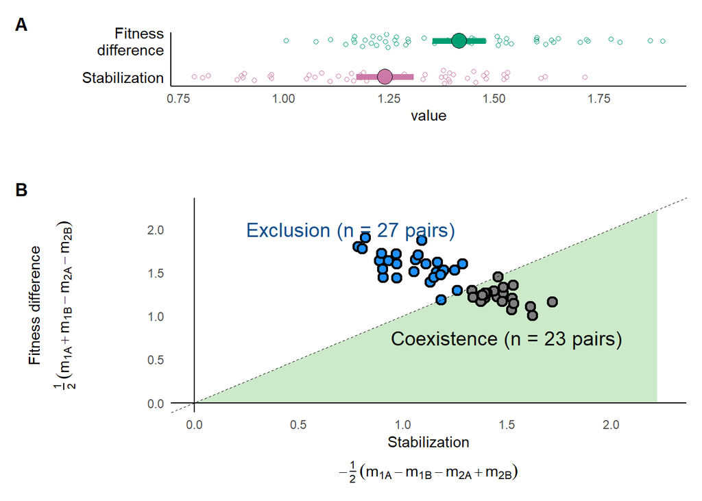

```r
# plotting points with simulated SD & FD, and label their predicted outcomes
base_coex_plot2 <- base_coex_plot
base_coex_plot2$layers[7] <- NULL
supfig_panel1 <-
  base_coex_plot2 +
  geom_point(data = fdsd_sim,
             aes(x = sd, y = fd, fill = coex),
             size = 2.5, shape = 21,
             stroke = 1.25) +
  scale_fill_manual(values = c("dodgerblue", "grey50")) +
  lims(x = c(0, 2.25),
       y = c(0, 2.25)) +
  geom_abline(linetype = 2, size = .25) +
  xlab(bquote(atop("Stabilization",
                   -frac(1,2)~(m["1A"]-m["1B"]-m["2A"]+m["2B"]) ))) +
  geom_text(aes(x = c(1.5, 0.75),
                y = c(0.75, 2),
                label = c('Coexistence (n = 23 pairs)',
                          'Exclusion (n = 27 pairs)')),
            color = c("grey5", "dodgerblue4"), size = 5)

# make dataframe to plot the SD and FD of datapoints and their mean horizontally
fdsd_sim_long <-
  fdsd_sim %>%
  select(-coex) %>%
  pivot_longer(fd:sd) %>%
  mutate(yval = ifelse(name == "fd", 1.5, 0.5))

fdsd_sim_sum <-
  fdsd_sim %>%
  select(-coex) %>%
  pivot_longer(fd:sd) %>%
  group_by(name) %>%
  summarize(mean = mean(value),
            sem = sd(value)/sqrt(n())) %>%
  mutate(yval = ifelse(name == "fd", 1.5, 0.5))

# plot those datapoints horizontally
supfig_panel2 <- ggplot(fdsd_sim_long) +
  geom_quasirandom(aes(x = value, y = yval, color = name),
                   fill = "transparent", width = 0.2,
                   pch = 21, groupOnX = F) +
  geom_errorbarh(data = fdsd_sim_sum ,
                 aes(xmin = mean-sem*2, xmax = mean+sem*2, y = yval, color = name),
                 size = 2, height = 0) +
  geom_point(data = fdsd_sim_sum, aes(x = mean, y = yval,  fill = name),
             pch = 21,size = 5) +
  theme_plots() +
  scale_y_continuous(name = "", breaks = c(0.5,1.5),
                     labels = c("Stabilization","Fitness\ndifference")) +

  scale_fill_manual(name = "Effect size", values = rev(c("#CC79A7", "#009E73"))) +
  scale_color_manual(name = "Effect size", values = rev(c("#CC79A7", "#009E73"))) +
  theme(axis.text.y = element_text(color = "black", size = 11))

# combine plots together
q2_reason_plot <- supfig_panel2 / plot_spacer() / supfig_panel1 +
  plot_annotation(tag_levels = "A") +
  plot_layout(heights = c(1,0.5, 4)) &
  theme(legend.position = "none")

# figure S.8
q2_reason_plot
```

```r
if(save_figures){
  ggsave("figures/q2_reason.png",
         q2_reason_plot, height = 6, width = 7)
}
```

### Fig.S.9: Univariate analysis of the strength of (de)stabilization

Instead of analyzing the *magnitude* of the (de)stabilizing effect (by taking the absolute value), here we analyze the actual value of the (de)stabilization metric. This is akin to the meta-analysis model of $I_S$ in Crawford et al. (2019)’s paper.

```r
# Univariate analysis of the stabilization metric

# combine data from both reference datasets
combined <- bind_rows(live_ref, sterile_ref)
# run a random effect model on the stabilization metric
combined_SD_efect <- rma.mv(mean_SD, V = var_SD,
                            random = list(~1|Experiment,
                                          ~1|species_pair),
                            data = combined)

combined_SD_efect
```

```
##
## Multivariate Meta-Analysis Model (k = 518; method: REML)
##
## Variance Components:
##
##             estim    sqrt  nlvls  fixed        factor
## sigma^2.1  0.0531  0.2304     81     no    Experiment
## sigma^2.2  0.0837  0.2893    263     no  species_pair
##
## Test for Heterogeneity:
## Q(df = 517) = 2782.1503, p-val < .0001
##
## Model Results:
##
## estimate      se    zval    pval   ci.lb   ci.ub
##   0.1000  0.0381  2.6259  0.0086  0.0254  0.1746  **
##
## ---
## Signif. codes:  0 '***' 0.001 '**' 0.01 '*' 0.05 '.' 0.1 ' ' 1
```

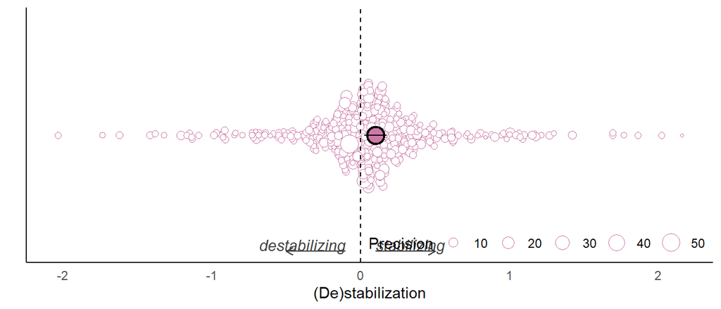

```r
# precision = 1/SE
combined$Precision <- (1/sqrt(combined$var_SD))

overall_stabilization_plot <-
  ggplot(combined) +
  ggbeeswarm::geom_beeswarm(aes(x = mean_SD,y = 0, size = Precision),
                            groupOnX = F, alpha = 1, stroke = 0.25, fill = "transparent",
                            shape = 21, color = "#CC79A7") +
  geom_point(aes(y = 0, x = combined_SD_efect$b), shape = 21,
             size = 5, fill = "#CC79A7", stroke = 1.25) +
  geom_errorbarh(aes(y = 0, xmin = combined_SD_efect$ci.lb,
                     xmax = combined_SD_efect$ci.ub), height = 0) +
  geom_vline(xintercept = 0, linetype = "dashed") +

  xlab("(De)stabilization") +
  ylab("") +
  scale_y_continuous(breaks = c(), limits = c(-0.5, 0.5)) +
  theme_plots() +
  annotate("text", x = 0.1, y = -Inf, hjust = 0, vjust = -1,
           label = "stabilizing", fontface = "italic", color = "grey25") +
  annotate("text", x = -0.1, y = -Inf, hjust = 1, vjust = -1,
           label = "destabilizing", fontface = "italic", color = "grey25") +
  annotate("segment", x = 0.1, xend = 0.5, y = -0.5, yend = -0.5,
           colour = "grey25", size = 0.5, arrow = arrow(length = unit(0.075, "inches"))) +
  annotate("segment", x = -0.1, xend = -0.5, y = -0.5, yend = -0.5,
           colour = "grey25", size = 0.5, arrow = arrow(length = unit(0.075, "inches"))) +

  theme(legend.position = c(1,0),
        legend.justification = c(1, 0),
        legend.direction = "horizontal")

overall_stabilization_plot
```

```r
if(save_figures) {
  ggsave("figures/overall_stabilization_plot.png",
         overall_stabilization_plot, width = 9, height = 2)
}
```

### Comparing our data extractions to Crawford et al.’s

Finally we want to verify that our data extraction protocol to get the estimates of plant growth in reference soils (using Web plot digitizer) gives the same results as Crawford et al’s extractions. To do this we re-extracted the relevant biomass values for 100+ estimates and compared our extractions to those of Crawford et al.

```r
# load data where we re-extracted part of the datat from Crawford et al. 2019
comparison_df <- read_csv("data/crawford-yan-extractions.csv")
# filter out the data that we didn't reextract
comparison_df_filt <- comparison_df %>%
  filter(!is.na(AinA_mean_reestimate))

# make dataframe to combine the original value and our re-extracted value
df_to_plot <- data.frame(crawford_estimates = c(comparison_df_filt$`AinA mean`,
                                                comparison_df_filt$`AinB mean`,
                                                comparison_df_filt$`BinA mean`,
                                                comparison_df_filt$`BinB mean`),
                         yan_reestimates = c(comparison_df_filt$AinA_mean_reestimate,
                                             comparison_df_filt$AinB_mean_reestimate,
                                             comparison_df_filt$BinA_mean_reestimate,
                                             comparison_df_filt$BinB_mean_reestimate))

# test the correlation of original vs. reextracted values
cor.test(df_to_plot$crawford_estimates, df_to_plot$yan_reestimates)
```

```
##
##  Pearson's product-moment correlation
##
## data:  df_to_plot$crawford_estimates and df_to_plot$yan_reestimates
## t = 1028.3, df = 106, p-value < 2.2e-16
## alternative hypothesis: true correlation is not equal to 0
## 95 percent confidence interval:
##  0.9999265 0.9999658
## sample estimates:
##       cor
## 0.9999499
```

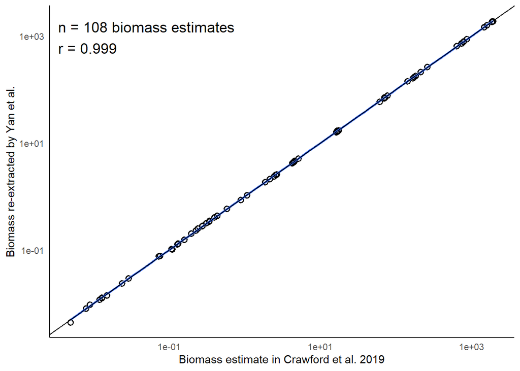

```r
# visualize the comparison
comparison_plot <-
  ggplot(df_to_plot, aes(x = crawford_estimates, y = yan_reestimates)) +
  geom_point(size = 2, shape = 21, stroke = 1) +
  geom_smooth(method = "lm") +
  geom_abline() +
  scale_x_log10() + scale_y_log10() +
  xlab("Biomass estimate in Crawford et al. 2019") +
  ylab("Biomass re-extracted by Yan et al.") +
  annotate('text', x = 0, y = Inf, hjust = 0,  vjust = 1.5,
           label = paste0("  n = ", nrow(df_to_plot), " biomass estimates\n  r = 0.999"),
           size = 5) +
  theme_plots()

comparison_plot
```

From both the correlation test and the visualization, our re-extracted values well correspond to the original values extracted by Crawford et al., indicating consistency in the data extraction by the two studies.

### Caterpillar-like plots

Finally, we made these catterpillar plots but were not able to include them in the paper – including here because they offer an alternative way of visualizing the effect sizes we are evaluating in this paper.

#### live reference dataset

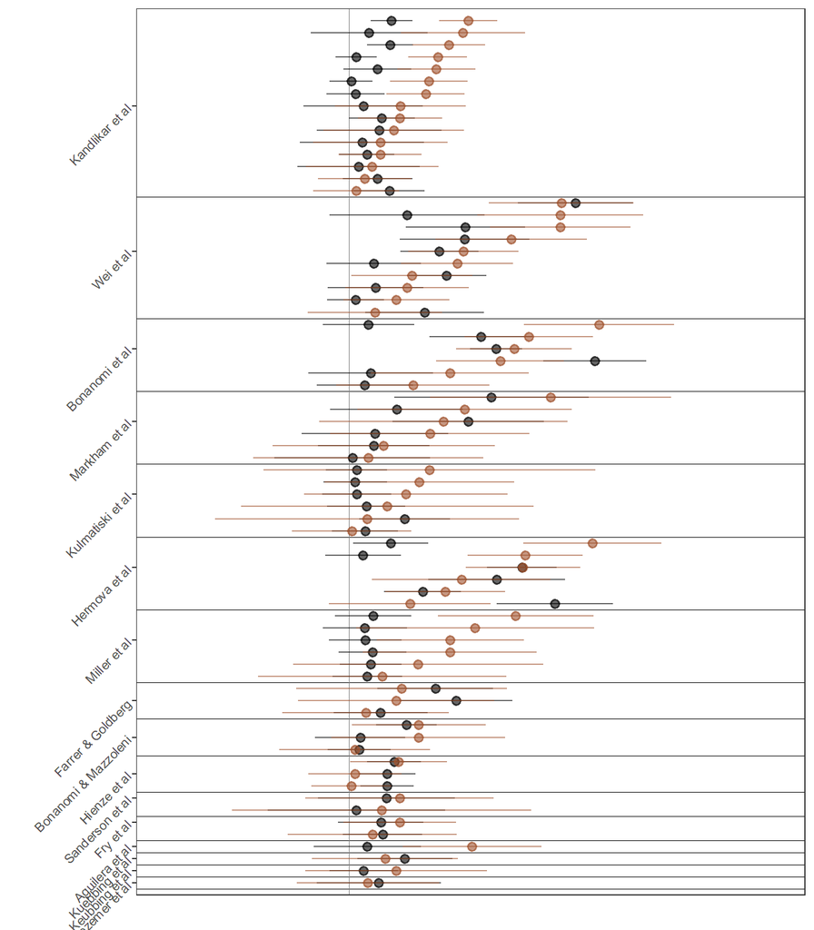

```r
# For Live soil reference ---------
live_ref_plot <-
  live_ref %>%
  # remove unneeded columns
  select(Experiment, Study, author, #Species_pair = `Species pair`,
         mean_FD, sem_FD, mean_SD, sem_SD) %>%
  group_by(Study, author) %>%
  # make new column for absolute value of FD and SD
  mutate(n = n(), abs_mean_FD = abs(mean_FD), abs_mean_SD = abs(mean_SD)) %>%
  # Arrange within group, descending by FD
  arrange(-abs_mean_FD, .by_group = T) %>%
  # Arrange so that groups (studies) with most rows are at top
  arrange(-n) %>%
  ungroup %>%
  # Add a new column with just the row number
  mutate(row_num = rev(row_number()))

# counts of datapoints per study
helper <- live_ref_plot %>%
  group_by(Study, author) %>%
  summarize(mean_row = ceiling(mean(row_num)),
            min_row = min(row_num))

# plotting
fx_plot <-
  ggplot(data = live_ref_plot) +
  scale_y_continuous(limits = c(0, 73), breaks = helper$mean_row,
                     labels = helper$author, expand = c(0,0)) +
  scale_x_continuous(limits = c(-1.5, 3.5)) +
  geom_hline(yintercept = helper$min_row - .5, size = .1) +
  geom_vline(xintercept = 0, linetype = 1, size = .25, color = "grey50") +
  geom_pointrange(aes(x = abs_mean_SD, y = row_num,
                      xmin = abs_mean_SD-2*sem_SD,
                      xmax = abs_mean_SD+2*sem_SD),
                  color =  alpha("black", .6)) +
  geom_pointrange(aes(x = abs_mean_FD, y = row_num,
                      xmin = abs_mean_FD-2*sem_FD,
                      xmax = abs_mean_FD+2*sem_FD),
                  color = alpha("Sienna", .6)) +
  scale_color_manual(values = c("sienna", "black"), name = "",
                     labels = c("Fitness difference",
                                "(De)stabilization") ) +
  geom_hline(yintercept = 0) +
  ylab("") +
  xlab("") +
  # theme_gsk() +
  theme_bw() +
  theme(axis.line.y= element_blank(),
        legend.position = "top",
        panel.grid = element_blank(),
        axis.text.y = element_text(angle = 45, size = 8),
        axis.text.x = element_blank(),
        axis.ticks.x = element_blank())

fx_plot
```

#### sterile reference dataset

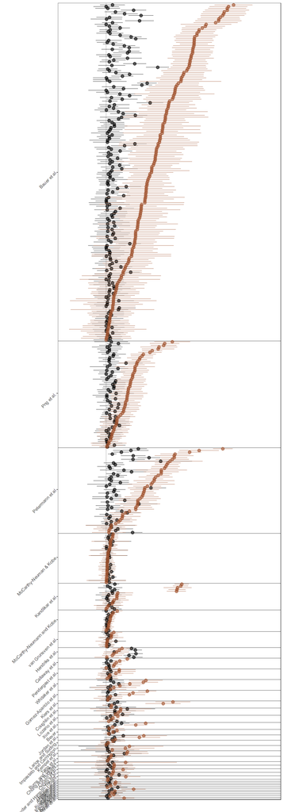

```r
# For sterile reference soil ----------
XS_ref_plot <-
  sterile_ref %>%
  # remove unneeded columns
  filter(mean_SD > -4) %>%
  select(Experiment, Study, author, #Species_pair = `Species pair`,
         mean_FD, sem_FD, mean_SD, sem_SD, control_type, study_control_type) %>%
  group_by(Study, author) %>%
  # make new column for absolute value of FD and SD
  mutate(n = n(), abs_mean_FD = abs(mean_FD), abs_mean_SD = abs(mean_SD)) %>%
  # Arrange within group, descending by FD
  arrange(-abs_mean_FD, .by_group = T) %>%
  # Arrange so that groups (studies) with most rows are at top
  arrange(-n) %>%
  ungroup %>%
  # Add a new column with just the row number
  mutate(row_num = rev(row_number()))

XS_helper <- XS_ref_plot %>%
  group_by(Study, author, study_control_type) %>%
  summarize(mean_row = ceiling(mean(row_num)),
            min_row = min(row_num))


xs_plot <-
  ggplot(data = XS_ref_plot) +
  scale_y_continuous(limits = c(0, nrow(XS_ref_plot) + 1),
                     breaks = XS_helper$mean_row, labels = XS_helper$author, expand = c(0,0)) +
  scale_x_continuous(limits = c(-1.5, 6.5)) +
  geom_hline(yintercept = XS_helper$min_row - .5, size = .1) +
  geom_vline(xintercept = 0, linetype = 1, size = .25, color = "grey50") +
  geom_pointrange(aes(x = abs_mean_SD, y = row_num,
                      xmin = abs_mean_SD-2*sem_SD,
                      xmax = abs_mean_SD+2*sem_SD),
                  color =  alpha("black", .6)) +
  geom_pointrange(aes(x = abs_mean_FD, y = row_num,
                      xmin = abs_mean_FD-2*sem_FD,
                      xmax = abs_mean_FD+2*sem_FD),
                  color = alpha("Sienna", .6)) +
    # geom_point(aes(x = -1.5, y = row_num,fill = control_type), shape = 21, stroke = 0, size = 2) +
  scale_color_manual(values = c("sienna", "black"), name = "",
                     labels = c("Fitness difference",
                                "(De)stabilization") ) +
  geom_hline(yintercept = 0) +
  ylab("") +
  xlab("") +
  theme_bw() +
  theme(axis.line.y= element_blank(),
        #legend.position = "top",
        panel.grid = element_blank(),
        axis.text.y = element_text(angle = 45, size = 8),
        axis.text.x = element_blank(),
        axis.ticks.x = element_blank())

xs_plot
```

```r
combined_catterpillars <- xs_plot + fx_plot

if(save_figures) {
  ggsave("figures/effectSize-catterpillars.png", combined_catterpillars,
         height = 12, width = 6)
}
```